# STAT5003_Final_Report

Group_50

Author: zilu0423 540245006 szha0052 530377698 ywan0228 530722304 yfan4715 510195249 whan4429 510074058 pwan0475 540453678

# 1 Overview of the problem

The aim of this project is to construct a model for predicting bank customer credit score, categorised into high, medium, and low. Banks need to get quite accurate predictions of the credit scores because this will be directly related to the lending decision and risk management.  
Traditional methods for assessment of credit are cumbersome, time-consuming, and sometimes not enough to represent the true financial status of a client. It is quite challenging for banks to evaluate the credit risk for the customer through traditional approaches, most notably in developing regions and when their customers are young.  
Thus, the project helps to ease this process of credit assessment for banks by building predictive models based on a variety of data points, including transaction history, employment status, and recent financial behaviour. Providing an equal playing field to individuals who don’t have credit history. Furthermore, proper credit scoring models may help banks offer tailor-made financial products that are more appropriate for their risk and financial position, which could increase customer satisfaction and reduce the rate of defaults.

# 2 Dataset description

The dataset is acquired from Kaggle and goes with the name “Credit Score Classification” by Rohan Paris (Paris, R, 2022). This is a credit information dataset of bank customers that aims to build a model for credit scoring. This dataset is under the Public Domain license, with the license of CC0: Public Domain.

The original dataset consists of 100,000 samples with 28 different attributes. Out of the attributes, 9 are numeric, and 19 are categorical. Data pre-processing resulted in an increase in the number of numerical attributes to 22, while the number of categorical attributes was reduced to 8. The credit scores are categorized into three classes of Poor, Standard and Good.

#### Description of major variables:

Among the many attributes, the following are particularly critical in predicting credit scores:

- Annual_Income: Represents the economic condition of customers and is an important indicator of credit evaluation based on the ability to pay.
- Num_of_Loan: These indicators reflect the number of loans of a customer and directly affect the credit score.
- Credit_Utilization_Ratio: A very high ratio indicates an increased credit risk and is one of the critical parameters for deciding the credit score.
- Num_of_Delayed_Payment and Delay_from_due_date: These are the key variables that indicate the repayment behavior of the customer and timings and thereby have a huge influence on the credit score.
- Monthly_Inhand_Salary: Direct impact on the liquidity situation for the customer and affecting his ability to repay the loan.

# 3 Initial data analysis/visualization of the data

For IDA, we start with a brief overview of all the features in the dataset to understand what is in the content and structure. We also identify and deal with the missing values, any form of outliers, and anomalies in the data to avoid potential model bias. Then, based on these analyses, the features with high rates of missing should either be dropped or imputed to keep the overall consistency and accuracy of the data set. Finally, we will represent the distribution and the relationship of features in a dataset graphically through bar plots, PCA and t-SNE to derive the patterns in data and separability between the categories.

## 3.1 Data Pre-processing

```r
# load package
suppressPackageStartupMessages({
  library(ggplot2)
  library(dplyr)
  library(tidyverse)
  library(caret)
  library(class)
  library(readr)
  library(MLmetrics)
  library(rpart)
  library(rpart.plot)
  library(randomForest)
  library(ranger)
  library(tree)
  library(e1071)
  library(lattice)
  library(stringr)
  library(visdat)
  library(plotly)
  library(pheatmap)
  library(Rtsne)
  library(zoo)
  library(reshape2)
})
```

```r
# load package
df <- read.csv("train.csv", stringsAsFactors = F)

# "set value for mode or random function"
getmode <- function(v) {
  uniqv <- unique(v)
  uniqv[which.max(tabulate(match(v, uniqv)))]
}

#"data cleaning for Month"
df$Month <- match(df$Month, month.name)

# "data cleaning for Name"
df <- df %>%
  mutate(Name = ifelse(Name == '', NA, Name)) %>%
  group_by(Customer_ID) %>%
  mutate(Name = coalesce(Name, getmode(Name[!is.na(Name)]))) %>%
  ungroup()

# "data cleaning for Age"
df <- df %>%
  mutate(Age = gsub("_", "", Age),
         Age = as.numeric(Age)) %>%
  mutate(Age = ifelse(Age == '' | Age > 90 | Age < 0, NA, Age)) %>%
  group_by(Customer_ID) %>%
  mutate(Age = coalesce(Age, getmode(Age[!is.na(Age)]))) %>%
  ungroup()

# "Labeling for Age"

#"Career Budding", "Career Development", "Career Maturity", "Career Decline"
df <- df %>%
  mutate(Age_Level = factor(case_when(
    Age <= 24 ~ 0,
    Age >= 25 & Age <= 34 ~ 1,
    Age >= 35 & Age <= 49 ~ 2,
    Age >= 50 ~ 3
  ), levels = 0:3)) %>%
  select(-Age)

# "data cleaning for SSN"
df <- df %>%
  mutate(SSN = ifelse(SSN == '#F%$D@*&8', NA, SSN)) %>%
  group_by(Customer_ID) %>%
  mutate(SSN = coalesce(SSN, getmode(SSN[!is.na(SSN)]))) %>%
  ungroup()

# "data cleaning for Occupation"
df <- df %>%
  mutate(Occupation = ifelse(Occupation == '_______', NA, Occupation)) %>%
  group_by(Customer_ID) %>%
  mutate(Occupation = coalesce(Occupation, getmode(Occupation[!is.na(Occupation)]))) %>%
  ungroup()

#"Labeling for Occupation"
occupation_stability <- c(
  "Lawyer" = 2, "Doctor" = 2, "Accountant" = 2, "Teacher" = 2, "Engineer" = 2,
  "Media_Manager" = 1, "Journalist" = 1, "Manager" = 1, "Scientist" = 1, "Architect" = 1, "Developer" = 1,
  "Entrepreneur" = 0, "Writer" = 0, "Musician" = 0, "Mechanic" = 0
)
df$Occupation <- occupation_stability[df$Occupation]
df$Occupation <- factor(df$Occupation)
invisible(levels(df$Occupation))

#"data cleaning for Annual_Income"
df <- df %>%
  mutate(Annual_Income = gsub("_", "", Annual_Income),
         Annual_Income = as.numeric(Annual_Income)) %>%
  mutate(Annual_Income = ifelse(Annual_Income == '', NA, Annual_Income)) %>%
  group_by(Customer_ID) %>%
  mutate(Annual_Income = coalesce(Annual_Income, getmode(Annual_Income[!is.na(Annual_Income)]))) %>%
  ungroup() %>%
  mutate(across(where(is.numeric), ~ round(., 2)))


# By querying outlier and normal value occurrence times
# Find the outlier limit of the Interest_Rate outlier limit. It is found that all outliers above 18w (including 18w) are outliers.

count_high_Annual_Income <- df %>%
  filter(Annual_Income >= 180000) %>%
  group_by(Customer_ID) %>%
  summarise(count_high_Annual_Income = n())

count <- df %>%
  group_by(Customer_ID) %>%
  summarise(count = n())

combined_df_Annual_Income <- left_join(count, count_high_Annual_Income, by = "Customer_ID")

# Will be higher than 18w(including 18w) according to Customer_ID unified
df <- df %>%
  mutate(Annual_Income = ifelse(Annual_Income == '' | Annual_Income >= 180000, NA, Annual_Income)) %>%
  group_by(Customer_ID) %>%
  mutate(Annual_Income = coalesce(Annual_Income, getmode(Annual_Income[!is.na(Annual_Income)]))) %>%
  ungroup()

# "Data cleaning for Annual_Income"

Q1.AI <- quantile(df$Annual_Income, 0.25)
Q3.AI <- quantile(df$Annual_Income, 0.75)
IQR.AI <- IQR(df$Annual_Income)

lower.AI <- Q1.AI - 1.5 * IQR.AI
upper.AI <- Q3.AI + 1.5 * IQR.AI

df <- subset(df, Annual_Income >= lower.AI & Annual_Income <= upper.AI)

# "data cleaning for Monthly_Inhand_Salary"
# Unify null values based on Customer_ID
df <- df %>%
  mutate(Monthly_Inhand_Salary = ifelse(Monthly_Inhand_Salary == '', NA, Monthly_Inhand_Salary)) %>%
  group_by(Customer_ID) %>%
  mutate(Monthly_Inhand_Salary = coalesce(Monthly_Inhand_Salary, getmode(Monthly_Inhand_Salary[!is.na(Monthly_Inhand_Salary)]))) %>%
  ungroup()

# "Data cleaning for Monthly_Inhand_Salary"

Q1.MIS <- quantile(df$Monthly_Inhand_Salary, 0.25)
Q3.MIS <- quantile(df$Monthly_Inhand_Salary, 0.75)
IQR.MIS <- IQR(df$Monthly_Inhand_Salary)

lower.MIS <- Q1.MIS - 1.5 * IQR.MIS
upper.MIS <- Q3.MIS + 1.5 * IQR.MIS

df <- subset(df, Monthly_Inhand_Salary >= lower.MIS & Monthly_Inhand_Salary <= upper.MIS)

# "data cleaning for Num_Bank_Accounts"

# By querying outlier and normal value occurrence times
# Find outlier bounds for Num_Bank_Accounts. It is found that all outliers above 12 (including 12) and -1 are outliers.
count_high_Num_Bank_Accounts <- df %>%
  filter(Num_Bank_Accounts >= 12) %>%
  group_by(Customer_ID) %>%
  summarise(count_high_Num_Bank_Accounts = n())

count <- df %>%
  group_by(Customer_ID) %>%
  summarise(count = n())

combined_df_Num_Bank_Accounts <- left_join(count, count_high_Num_Bank_Accounts, by = "Customer_ID")

invisible(combined_df_Num_Bank_Accounts)

# will be higher than 12 (including 12) and lower than 0 according to the Customer_ID unified
df <- df %>%
  mutate(Num_Bank_Accounts = ifelse(Num_Bank_Accounts == '' | Num_Bank_Accounts >= 12 | Num_Bank_Accounts < 0, NA, Num_Bank_Accounts)) %>%
  group_by(Customer_ID) %>%
  mutate(Num_Bank_Accounts = coalesce(Num_Bank_Accounts, getmode(Num_Bank_Accounts[!is.na(Num_Bank_Accounts)]))) %>%
  ungroup()

# "Data cleaning for Num_Bank_Accounts"

Q1.NBA <- quantile(df$Num_Bank_Accounts, 0.25)
Q3.NBA <- quantile(df$Num_Bank_Accounts, 0.75)
IQR.NBA <- IQR(df$Num_Bank_Accounts)

lower.NBA <- Q1.NBA - 1.5 * IQR.NBA
upper.NBA <- Q3.NBA + 1.5 * IQR.NBA

df <- subset(df, Num_Bank_Accounts >= lower.NBA & Num_Bank_Accounts <= upper.NBA)

# "data cleaning for Num_Credit_Card"


count_high_credit_card <- df %>%
  filter(Num_Credit_Card >= 12) %>%
  group_by(Customer_ID) %>%
  summarise(Count_High_Credit_Card = n())

count <- df %>%
  group_by(Customer_ID) %>%
  summarise(count = n())

combined_df_credit_card <- left_join(count, count_high_credit_card, by = "Customer_ID")

df <- df %>%
  mutate(Num_Credit_Card = ifelse(Num_Credit_Card == '' | Num_Credit_Card >= 12, NA, Num_Credit_Card)) %>%
  group_by(Customer_ID) %>%
  mutate(Num_Credit_Card = coalesce(Num_Credit_Card, getmode(Num_Credit_Card[!is.na(Num_Credit_Card)]))) %>%
  ungroup()
```

```r
# "Data cleaning for Num_Credit_Card"

Q1.NCC <- quantile(df$Num_Credit_Card, 0.25)
Q3.NCC <- quantile(df$Num_Credit_Card, 0.75)
IQR.NCC <- IQR(df$Num_Credit_Card)

lower.NCC <- Q1.NCC - 1.5 * IQR.NCC
upper.NCC <- Q3.NCC + 1.5 * IQR.NCC

df <- subset(df, Num_Credit_Card >= lower.NCC & Num_Credit_Card <= upper.NCC)

# "data cleaning for Interest_Rate"
count_high_Interest_Rate <- df %>%
  filter(Interest_Rate >= 35) %>%
  group_by(Customer_ID) %>%
  summarise(count_high_Interest_Rate = n())

count <- df %>%
  group_by(Customer_ID) %>%
  summarise(count = n())

combined_df_Interest_Rate <- left_join(count, count_high_Interest_Rate, by = "Customer_ID")


df <- df %>%
  mutate(Interest_Rate = ifelse(Interest_Rate == '' | Interest_Rate >= 35, NA, Interest_Rate)) %>%
  group_by(Customer_ID) %>%
  mutate(Interest_Rate = coalesce(Interest_Rate, getmode(Interest_Rate[!is.na(Interest_Rate)]))) %>%
  ungroup()

# "Data cleaning for Interest_Rate"

Q1.IR <- quantile(df$Interest_Rate, 0.25)
Q3.IR <- quantile(df$Interest_Rate, 0.75)
IQR.IR <- IQR(df$Interest_Rate)

lower.IR <- Q1.IR - 1.5 * IQR.IR
upper.IR <- Q3.IR + 1.5 * IQR.IR

df <- subset(df, Interest_Rate >= lower.IR & Interest_Rate <= upper.IR)

# "data cleaning for Num_of_Loan"

df <- df %>%
  mutate(Num_of_Loan = ifelse(Type_of_Loan == '', 0,
                              ifelse(str_detect(Type_of_Loan, ','),
                                     str_count(Type_of_Loan, ',') + 1,
                                     1)))

# Find the unique Type_of_Loan (9 types)
df_loans <- df %>%
  separate_rows(Type_of_Loan, sep = ", and |, ") %>%
  mutate(Type_of_Loan = trimws(Type_of_Loan)) %>%
  filter(Type_of_Loan != '')

loan_type_categories <- c(
  "Credit-Builder Loan" = "Credit Building",
  "Home Equity Loan" = "Housing",
  "Not Specified" = "Unspecified",
  "Payday Loan" = "Personal Consumption",
  "Student Loan" = "Education",
  "Debt Consolidation Loan" = "Debt Consolidation",
  "Personal Loan" = "Personal Consumption",
  "Auto Loan" = "Personal Consumption",
  "Mortgage Loan" = "Housing"
)
df <- df %>%
  mutate(Credit_Building = as.integer(grepl("Credit-Builder Loan", Type_of_Loan)),
         Housing = as.integer(grepl("Home Equity Loan|Mortgage Loan", Type_of_Loan)),
         Unspecified = as.integer(grepl("Not Specified", Type_of_Loan)),
         Personal_Consumption = as.integer(grepl("Payday Loan|Personal Loan|Auto Loan", Type_of_Loan)),
         Education = as.integer(grepl("Student Loan", Type_of_Loan)),
         Debt_Consolidation = as.integer(grepl("Debt Consolidation Loan", Type_of_Loan))) %>%
  select(-Type_of_Loan)

# "data cleaning for Delay_from_due_date"

# numeric
df <- df %>%
  mutate(Delay_from_due_date = as.numeric(Delay_from_due_date))

# "Data cleaning for Delay_from_due_date"

Q1.DDD <- quantile(df$Delay_from_due_date, 0.25)
Q3.DDD <- quantile(df$Delay_from_due_date, 0.75)
IQR.DDD <- IQR(df$Delay_from_due_date)

lower.DDD <- Q1.DDD - 1.5 * IQR.DDD
upper.DDD <- Q3.DDD + 1.5 * IQR.DDD

df <- subset(df, Delay_from_due_date >= lower.DDD & Delay_from_due_date <= upper.DDD)

# "data cleaning for Num_of_Delayed_Payment"

# By querying outlier and normal value occurrence times
# Find the outlier bounds for Num_of_Delayed_Payment's outlier bounds. It is found that outliers above 29 (including 29) and below 0 are outliers.

count_high_Num_of_Delayed_Payment <- df %>%
  filter(Num_of_Delayed_Payment >= 29) %>%
  group_by(Customer_ID) %>%
  summarise(count_high_Num_of_Delayed_Payment = n())

count <- df %>%
  group_by(Customer_ID) %>%
  summarise(count = n())

combined_df_Num_of_Delayed_Payment <- left_join(count, count_high_Num_of_Delayed_Payment, by = "Customer_ID")


# Unify values above 29(including 29) and below 0 according to Customer_ID, and delete underscores,
df <- df %>%
  mutate(Num_of_Delayed_Payment = gsub("_", "", Num_of_Delayed_Payment),
         Num_of_Delayed_Payment = as.numeric(Num_of_Delayed_Payment),
         Num_of_Delayed_Payment = ifelse(Num_of_Delayed_Payment == '' | Num_of_Delayed_Payment >= 29 | Num_of_Delayed_Payment < 0, NA, Num_of_Delayed_Payment)) %>%
  group_by(Customer_ID) %>%
  mutate(Num_of_Delayed_Payment = coalesce(Num_of_Delayed_Payment, getmode(Num_of_Delayed_Payment[!is.na(Num_of_Delayed_Payment)]))) %>%
  ungroup() %>%
  filter(!is.na(Num_of_Delayed_Payment))

# "Data cleaning for Num_of_Delayed_Payment"

Q1.NDP <- quantile(df$Num_of_Delayed_Payment, 0.25)
Q3.NDP <- quantile(df$Num_of_Delayed_Payment, 0.75)
IQR.NDP <- IQR(df$Num_of_Delayed_Payment)

lower.NDP <- Q1.NDP - 1.5 * IQR.NDP
upper.NDP <- Q3.NDP + 1.5 * IQR.NDP

df <- subset(df, Num_of_Delayed_Payment >= lower.NDP & Num_of_Delayed_Payment <= upper.NDP)

# "data cleaning for Changed_Credit_Limit"

# Delete the '_' after the value, then delete all empty lines
df <- df %>%
  mutate(Changed_Credit_Limit = gsub("_", "", Changed_Credit_Limit)) %>%
  mutate(Changed_Credit_Limit = as.numeric(Changed_Credit_Limit)) %>%
  drop_na(Changed_Credit_Limit) %>%
  mutate(across(where(is.numeric), ~ round(., 2)))

# "Data cleaning for Changed_Credit_Limit"

Q1.CCL <- quantile(df$Changed_Credit_Limit, 0.25)
Q3.CCL <- quantile(df$Changed_Credit_Limit, 0.75)
IQR.CCL <- IQR(df$Changed_Credit_Limit)

lower.CCL <- Q1.CCL - 1.5 * IQR.CCL
upper.CCL <- Q3.CCL + 1.5 * IQR.CCL

df <- subset(df, Changed_Credit_Limit >= lower.CCL & Changed_Credit_Limit <= upper.CCL)

# "data cleaning for Num_Credit_Inquiries"

# By querying outlier and normal value occurrence times
# Find outlier bounds for Num_Credit_Inquiries outlier bounds. All outliers above 18 (including 18) are found to be outliers.

count_high_Num_Credit_Inquiries <- df %>%
  filter(Num_Credit_Inquiries >= 18) %>%
  group_by(Customer_ID) %>%
  summarise(count_high_Num_Credit_Inquiries = n())

count <- df %>%
  group_by(Customer_ID) %>%
  summarise(count = n())

combined_df_Num_Credit_Inquiries <- left_join(count, count_high_Num_Credit_Inquiries, by = "Customer_ID")

invisible(combined_df_Num_Credit_Inquiries)

# But since 18 counts is too small, I locate 32 counts including (32) as outliers.
# Will be higher than 32(including 32) based on Customer_ID unified
df <- df %>%
  mutate(Num_Credit_Inquiries = ifelse(Num_Credit_Inquiries == '' | Num_Credit_Inquiries >= 32, NA, Num_Credit_Inquiries)) %>%
  group_by(Customer_ID) %>%
  mutate(Num_Credit_Inquiries = coalesce(Num_Credit_Inquiries, getmode(Num_Credit_Inquiries[!is.na(Num_Credit_Inquiries)]))) %>%
  ungroup() %>%
  filter(!is.na(Num_Credit_Inquiries))
```

```r
#| code-summary: "Data cleaning for Num_Credit_Inquiries"

Q1.NCI <- quantile(df$Num_Credit_Inquiries, 0.25)
Q3.NCI <- quantile(df$Num_Credit_Inquiries, 0.75)
IQR.NCI <- IQR(df$Num_Credit_Inquiries)

lower.NCI <- Q1.NCI - 1.5 * IQR.NCI
upper.NCI <- Q3.NCI + 1.5 * IQR.NCI

df <- subset(df, Num_Credit_Inquiries >= lower.NCI & Num_Credit_Inquiries <= upper.NCI)


# "data cleaning for Credit_Mix"

# Credit_Mix
df <- df %>%
  mutate(Credit_Mix = ifelse(Credit_Mix == '_', NA, Credit_Mix)) %>%
  group_by(Customer_ID) %>%
  mutate(Credit_Mix = coalesce(Credit_Mix, getmode(Credit_Mix[!is.na(Credit_Mix)]))) %>%
  ungroup() %>%
  filter(!is.na(Credit_Mix))

# "Labeling for Credit_Mix"
df$Credit_Mix <- factor(df$Credit_Mix, levels = c("Bad", "Standard", "Good"), labels = c(0, 1, 2), ordered = TRUE)
invisible(levels(df$Credit_Mix))

# "data cleaning for Outstanding_Debt"

# Outstanding_Debt
df$Outstanding_Debt <- gsub("_", "", df$Outstanding_Debt)
df$Outstanding_Debt <- as.numeric(df$Outstanding_Debt)

# "Data cleaning for Outstanding_Debt"

Q1.OD <- quantile(df$Outstanding_Debt, 0.25)
Q3.OD <- quantile(df$Outstanding_Debt, 0.75)
IQR.OD <- IQR(df$Outstanding_Debt)

lower.OD <- Q1.OD - 1.5 * IQR.OD
upper.OD <- Q3.OD + 1.5 * IQR.OD

df <- subset(df, Outstanding_Debt >= lower.OD & Outstanding_Debt <= upper.OD)

# "Data cleaning for Credit_Utilization_Ratio"

Q1.CUR <- quantile(df$Credit_Utilization_Ratio, 0.25)
Q3.CUR <- quantile(df$Credit_Utilization_Ratio, 0.75)
IQR.CUR <- IQR(df$Credit_Utilization_Ratio)

lower.CUR <- Q1.CUR - 1.5 * IQR.CUR
upper.CUR <- Q3.CUR + 1.5 * IQR.CUR

df <- subset(df, Credit_Utilization_Ratio >= lower.CUR & Credit_Utilization_Ratio <= upper.CUR)

# "data cleaning for Credit_History_Age"

df <- df %>%
  mutate(Credit_History_Age = gsub("Years and ", "", Credit_History_Age),
         Credit_History_Age = gsub("Months", "", Credit_History_Age),
         Credit_History_Age = gsub("Month", "", Credit_History_Age),
         Credit_History_Age = gsub("\\[\\s+\\]", " ", trimws(Credit_History_Age)),
         Credit_History_Age_Months = as.numeric(sub("\\s.*", "", Credit_History_Age)) * 12 +
                                     as.numeric(gsub(".*\\s", "", Credit_History_Age))) %>%
  select(-Credit_History_Age)

fill_na <- function(x) {
  if (all(is.na(x))) {
    return(x)
  }

  x[is.na(x)] <- zoo::na.locf(x, na.rm = FALSE, fromLast = FALSE)[is.na(x)]
  return(x)
}

df <- df %>%
  group_by(Customer_ID) %>%
  arrange(Customer_ID, Month, .by_group = TRUE) %>%
  mutate(Credit_History_Age_Months = fill_na(Credit_History_Age_Months)) %>%
  ungroup() %>%
  mutate(Credit_History_Age = paste0(floor(Credit_History_Age_Months / 12), " Years and ",
                                     Credit_History_Age_Months %% 12, " Months")) %>%
  select(-Credit_History_Age_Months)

df <- df %>%
  mutate(Credit_History_Age = gsub("NA", "", Credit_History_Age),
         Credit_History_Age = gsub("Years and ", "", Credit_History_Age),
         Credit_History_Age = gsub("Months", "", Credit_History_Age),
         Credit_History_Age = gsub("Years", "", Credit_History_Age),
         Credit_History_Age = gsub("\\[\\s+\\]", " ", trimws(Credit_History_Age)),
         Credit_History_Age = as.numeric(sub("\\s.*", "", Credit_History_Age)) +
                               as.numeric(gsub(".*\\s", "", Credit_History_Age)) / 12) %>%
  filter(!is.na(Credit_History_Age))

# "Data cleaning for Payment_of_Min_Amount"

get_mode <- function(x) {
  ux <- unique(x[!is.na(x)])
  if (length(ux) > 0) {
    ux[which.max(tabulate(match(x, ux)))]
  } else {
    NA
  }
}

df <- df %>%
  group_by(Customer_ID) %>%
  mutate(Payment_of_Min_Amount = ifelse(Payment_of_Min_Amount == "NM",
                                        get_mode(Payment_of_Min_Amount[Payment_of_Min_Amount != "NM"]),
                                        Payment_of_Min_Amount)) %>%
  ungroup() %>%
  filter(!is.na(Payment_of_Min_Amount))

df$Payment_of_Min_Amount <- factor(df$Payment_of_Min_Amount, levels = c("No", "Yes"), labels = c(0, 1), ordered = TRUE)

# "Data cleaning for Total_EMI_per_month"

Q1.EMI <- quantile(df$Total_EMI_per_month, 0.25)
Q3.EMI <- quantile(df$Total_EMI_per_month, 0.75)
IQR.EMI <- IQR(df$Total_EMI_per_month)

lower.EMI <- Q1.EMI - 1.5 * IQR.EMI
upper.EMI <- Q3.EMI + 1.5 * IQR.EMI

df <- subset(df, Total_EMI_per_month >= lower.EMI & Total_EMI_per_month <= upper.EMI)

# "Summarise Amount_invested_monthly"

df <- df %>%
  mutate(Amount_invested_monthly = as.numeric(gsub("__10000__", NA, Amount_invested_monthly))) %>%
  filter(!is.na(Amount_invested_monthly))

# "Data cleaning for Amount_invested_monthly"

Q1.AIM <- quantile(df$Amount_invested_monthly, 0.25)
Q3.AIM <- quantile(df$Amount_invested_monthly, 0.75)
IQR.AIM <- IQR(df$Amount_invested_monthly)

lower.AIM <- Q1.AIM - 1.5 * IQR.AIM
upper.AIM <- Q3.AIM + 1.5 * IQR.AIM

# drop
df <- subset(df, Amount_invested_monthly >= lower.AIM & Amount_invested_monthly <= upper.AIM)

# "Data cleaning for Payment_Behaviour"

df <- df %>%
  mutate(Payment_Behaviour = case_when(
    Payment_Behaviour == "Low_spent_Small_value_payments" ~ 0,
    Payment_Behaviour == "Low_spent_Medium_value_payments" ~ 1,
    Payment_Behaviour == "Low_spent_Large_value_payments" ~ 2,
    Payment_Behaviour == "High_spent_Large_value_payments" ~ 3,
    Payment_Behaviour == "High_spent_Medium_value_payments" ~ 4,
    Payment_Behaviour == "High_spent_Small_value_payments" ~ 5,
    Payment_Behaviour == "!@9#%8" ~ as.numeric(NA),
    TRUE ~ as.numeric(NA)
  ))

get_rand_mode <- function(x) {
  ux <- unique(na.omit(x))
  if (length(ux) > 0) {
    return(sample(ux, 1))
  } else {
    return(NA)
  }
}

payment_behaviour_mode <- df %>%
  group_by(Customer_ID) %>%
  summarise(Payment_Behaviour_Mode = get_rand_mode(Payment_Behaviour))

df <- left_join(df, payment_behaviour_mode, by = "Customer_ID")
df$Payment_Behaviour <- coalesce(df$Payment_Behaviour, df$Payment_Behaviour_Mode)

df <- df %>% filter(!is.na(Payment_Behaviour))
df <- df %>%
  select(-Payment_Behaviour_Mode)
df$Payment_Behaviour <- as.factor(df$Payment_Behaviour)
```

```r
#| code-summary: "Data cleaning for Monthly_Balance"

df <- df %>%
  filter(Monthly_Balance != "__-333333333333333333333333333__") %>%
  filter(!is.na(Monthly_Balance)) %>%
  mutate(Monthly_Balance = as.numeric(gsub("[^0-9.-]+", "", Monthly_Balance))) %>%
  filter(!is.na(Monthly_Balance))

# "Data cleaning for Monthly_Balance"

Q1.MB <- quantile(df$Monthly_Balance, 0.25)
Q3.MB <- quantile(df$Monthly_Balance, 0.75)
IQR.MB <- IQR(df$Monthly_Balance)

lower.MB <- Q1.MB - 1.5 * IQR.MB
upper.MB <- Q3.MB + 1.5 * IQR.MB

df <- subset(df, Monthly_Balance >= lower.MB & Monthly_Balance <= upper.MB)

# Labeling
df$Credit_Score <- factor(df$Credit_Score, levels = c("Poor", "Standard", "Good"), labels = c(0, 1, 2), ordered = TRUE)
```

Following are the preprocessing tasks with the dataset to make the model run accurately and efficiently.

- Customer Information: ID, Customer_ID, Name, SSN. Basic information needs no processing. The fill-in uses the customer ID for null values or abnormal values.
- Time Information: The text month is converted into a number.
- Economic Information: For instance, Annual_Income, Monthly_Inhand_Salary, Num_Bank_Accounts, Num_Credit_Card, and Interest_Rate: handle outliers and clean the data using the IQR method.
- Loan Information: Num_of_Loan and Type_of_Loan. Derived Variables: Housing, Education, etc. Handle the missing values and outliers, reclassify the Type of Loan and obtain the numeric type.
- Credit Information: Delay_from_due_date, Num_of_Delayed_Payment, Changed_Credit_Limit, Outstanding_Debt, Credit_Utilization_Ratio, Total_EMI_per_month, Monthly_Balance: formatting adjustments and removal of outliers using the IQR method.
- History Information: Credit_History_Age: format change and grouped by customer ID to impute any missing values.
- Other Informations (Credit_Mix, Payment_of_Min_Amount, Amount_invested_monthly, Payment_Behaviour, Credit_Score) :handle null values and outliers, convert formats and standardize appropriately.

## 3.2 Data Visualization

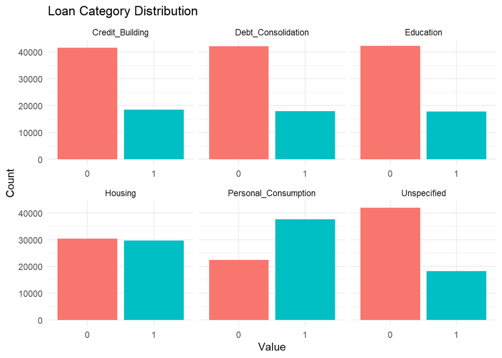

```r
# plot loan type
loan.categories <- df %>%
  select(Credit_Building, Housing, Unspecified, Personal_Consumption, Education, Debt_Consolidation) %>%
  pivot_longer(cols = everything(), names_to = "Loan_Category", values_to = "Value") %>%
  group_by(Loan_Category, Value) %>%
  summarise(Count = n(), .groups = "drop")

ggplot(data = loan.categories, aes(x = factor(Value), y = Count, fill = factor(Value))) +
  geom_bar(stat = "identity") +
  facet_wrap(~ Loan_Category, scales = "free_x") +
  labs(title = "Loan Category Distribution",
       x = "Value",
       y = "Count") +
  theme_minimal() +
  theme(axis.text.x = element_text(angle = 0, hjust = 0.5),
        legend.position = "none")
```

#### Bar Chart

The bar chart shows the distribution of the different loan categories in the dataset. For each loan category, the distribution is based on two values: 0 (missing) and 1 (existing). It is clear to see that personal consumption loans are relatively high in the dataset and the distribution of housing loans is relatively balanced.

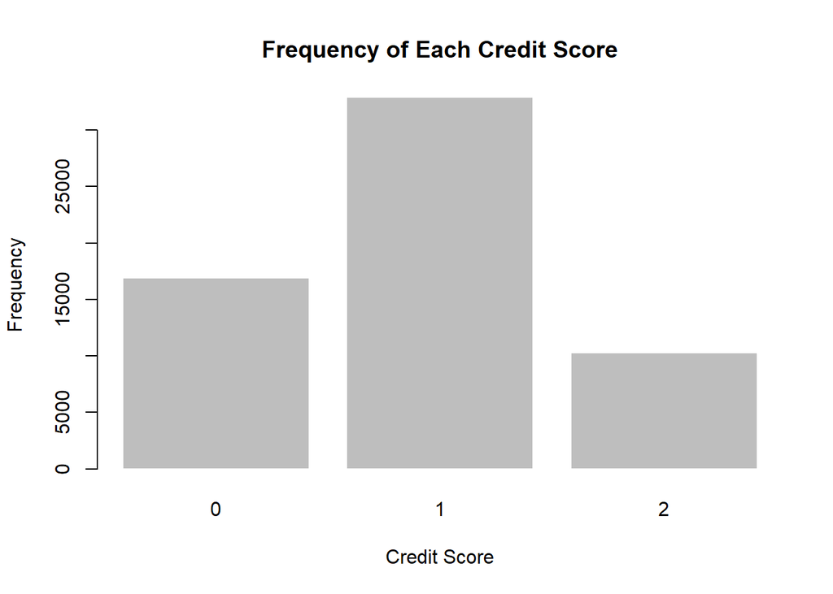

```r
# plot frequency of each credit score
credit_score_counts <- table(df$Credit_Score)
barplot(credit_score_counts,
        main = "Frequency of Each Credit Score",
        xlab = "Credit Score",
        ylab = "Frequency",
        col = "grey",
        border = "white")
```

#### Bar Chart

The figure shows the distribution of the target feature in this dataset. From the figure, we can see that the visualization shows that there is a certain imbalance in the distribution of different credit score categories. Class 1 (Standard) appears most frequently and far exceeds class 0 (Poor) and class 2 (Good). It indicates that the credit scores of the vast majority of people are distributed in Standard, reflecting the general credit status of the group. The problem of class imbalance will bring challenges to the model building stage. It will bias classification models toward the majority class and result in poor accuracy in the classification of minor classes. So we need to consider the sensitivity of the model to unbalanced data in the model selection stage.

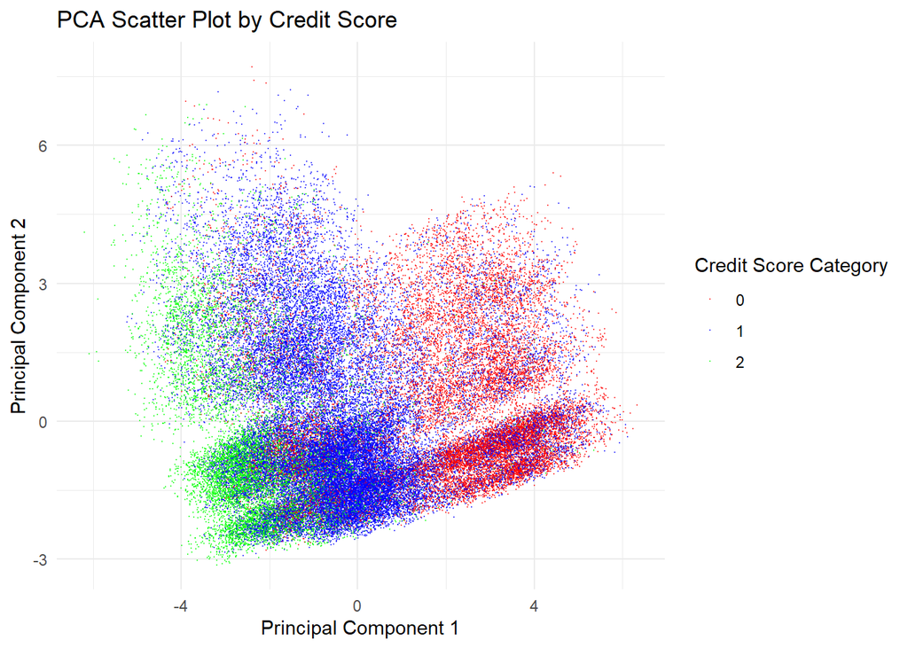

```r
# plot PCA
df6 <- subset(df,select = -c(Month,ID,Customer_ID,SSN,Name))

numerical_cols <- c("Annual_Income", "Monthly_Inhand_Salary", "Num_Bank_Accounts", "Num_Credit_Card",
                    "Interest_Rate", "Num_of_Loan", "Delay_from_due_date", "Num_of_Delayed_Payment",
                    "Changed_Credit_Limit", "Num_Credit_Inquiries", "Outstanding_Debt",
                    "Credit_Utilization_Ratio", "Total_EMI_per_month", "Amount_invested_monthly",
                     "Monthly_Balance", "Credit_Score")

dataNumeric <- df6[, numerical_cols]
dataNumeric$Credit_Score <- as.numeric(as.character(dataNumeric$Credit_Score))

# Applying PCA
pca_result <- prcomp(dataNumeric, scale. = TRUE)

# Convert PCA scores to data boxes
scores_df <- as.data.frame(pca_result$x)

# Add target feature
scores_df$Credit_Score <- dataNumeric$Credit_Score

# Plot Scatter graph
ggplot(scores_df, aes(x = PC1, y = PC2, color = as.factor(Credit_Score))) +
  geom_point(alpha = 0.5, size = 0.00000000005) +
  labs(title = "PCA Scatter Plot by Credit Score", x = "Principal Component 1", y = "Principal Component 2", color = "Credit Score Category") +
  scale_color_manual(values = c("red", "blue", "green")) +
  theme_minimal()
```

#### PCA

From the scatter plot of PCA, we can find the distribution of data categories. Scores of different categories overlap a lot in the principal component space, which may indicate that the model based on linear methods may not perform well on this data set and cannot effectively distinguish different categories. Further feature extraction or the use of complex models capable of dealing with nonlinear relationships may be required, and certain imbalances may be found from them, to deal with this we may need some data processing strategies to improve the model’s ability to predict a few classes.

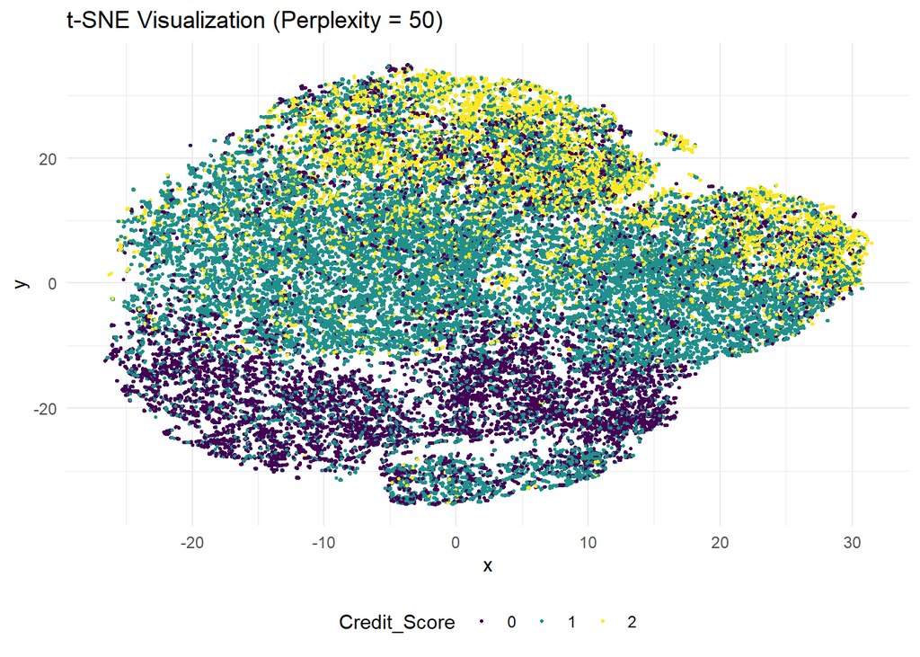

```r
# plot t-SNE
df6 <- subset(df,select = -c(Month,ID,Customer_ID,SSN,Name))
set.seed(510195249)

# Define the numerical columns
numerical_cols <- c("Annual_Income", "Monthly_Inhand_Salary", "Num_Bank_Accounts", "Num_Credit_Card",
                    "Interest_Rate", "Num_of_Loan", "Delay_from_due_date", "Num_of_Delayed_Payment",
                    "Changed_Credit_Limit", "Num_Credit_Inquiries", "Outstanding_Debt",
                    "Credit_Utilization_Ratio", "Total_EMI_per_month", "Amount_invested_monthly",
                    "Monthly_Balance", "Credit_History_Age")

df_filtered <- df6 %>%
  filter(if_all(all_of(numerical_cols), ~ !is.na(.)))
df_numerical_scaled <- scale(df_filtered[, numerical_cols])

tsne_result <- Rtsne(df_numerical_scaled, dims = 2, perplexity = 50, max_iter = 1000, pca = TRUE)$Y
tsne_data <- as.data.frame(tsne_result)
names(tsne_data) <- c("x", "y")
tsne_data[["Credit_Score"]] <- df_filtered[["Credit_Score"]]

tsne_plot <- ggplot(tsne_data, aes(x = x, y = y, colour = Credit_Score)) +
    geom_point(size = 0.5) +
    ggtitle("t-SNE Visualization (Perplexity = 50)") +
    theme_minimal() +
    theme(legend.position = "bottom")

print(tsne_plot)
```

#### t-SNE

For an enhanced knowledge on how to distribute the data from the high-dimension feature space into various categories in a credit score, we employed t-distributed Stochastic Neighbour Embedding (t-SNE), which is a non-linear dimensionality reduction technique in such a way that pairwise similarities between data points are best preserved (Hamid & M. Sugumaran, 2019). In the project, we set the perplexity at 50, and plot the whole numerical features using t-SNE. From the plot, it can be seen that the “1”(Standard) customers spread more, taking much space to cover the centre and the right part of the plot, meaning that their features are diversified. Meanwhile, three categories overlap each other, suggesting that the differentiation between customers of different credit scores cannot be perfectly done with the current dimension of features.

# 4 Feature engineering

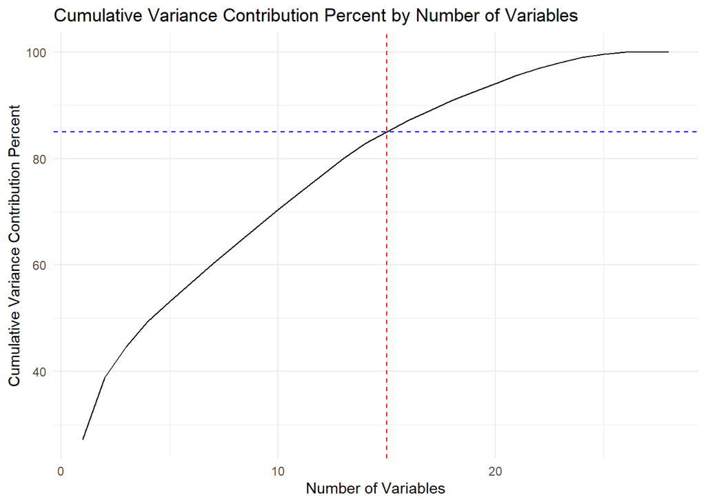

```r
# feature engineering
df3 <- df
df3 <- subset(df3,select = -c(Month,ID,Customer_ID,SSN,Name))
df3 <- df3 %>%
  mutate(across(where(is.factor), ~as.numeric(as.character(.)))) %>%
  mutate(across(where(is.numeric), ~ifelse(is.na(.), median(., na.rm = TRUE), .))) %>%
  mutate(across(where(is.numeric), scale))
df3 <- df3[complete.cases(df3$Credit_History_Age), ]

# Call prcomp function
pca_result <- prcomp(df3, scale. = TRUE)
# Output explained variances and factor loading matrix
variance_explained <- pca_result$sdev^2 / sum(pca_result$sdev^2)
#Define contribute percent of variance
variance_contrib_percent <- (pca_result$sdev^2 / sum(pca_result$sdev^2)) * 100
# Define cumulative contribute percent of variance
cumulative_variance_contrib_percent <- cumsum(variance_contrib_percent)
# Calculate the (cumulative) percentage variance contribution
variance_contrib_percent <- (pca_result$sdev^2 / sum(pca_result$sdev^2)) * 100
cumulative_variance_contrib_percent <- cumsum(variance_contrib_percent)

# Setting determine to output names till cvcp > 85%
selected_variables <- names(cumulative_variance_contrib_percent[cumulative_variance_contrib_percent > 85])

# Filter cumulative variance contribute percent when over 85%
df4 <- data.frame(cumulative_variance_contrib_percent, variable = names(df3))

selected_variables <- df4$variable[df4$cumulative_variance_contrib_percent < 86]
df5 <- df[selected_variables]
credit_score_column <- df$Credit_Score
df5_with_credit_score <- cbind(df5, Credit_Score = credit_score_column)
df5_with_credit_score <- mutate_if(df5_with_credit_score, is.factor, as.character)
df5_with_credit_score <- mutate_all(df5_with_credit_score, as.numeric)


# Create a data frame with variable names and their cumulative percent contributions
df_cumulative <- data.frame(
  variables = names(df3),
  cumulative_percent = cumulative_variance_contrib_percent
)

# Calculate the index where the cumulative percent is just under 86%
max_index_under_86 <- max(which(df_cumulative$cumulative_percent < 86))

# Retrieve the cumulative percent at this index to use for the horizontal line
selected_percent = df_cumulative$cumulative_percent[max_index_under_86]

# Plotting the graph
ggplot(df_cumulative, aes(x = seq_along(variables), y = cumulative_percent)) +
  geom_line() +  # Draw the line plot
  geom_vline(xintercept = max_index_under_86, color = "red", linetype = "dashed") +
  geom_hline(yintercept = selected_percent, color = "blue", linetype = "dashed") +
  labs(title = "Cumulative Variance Contribution Percent by Number of Variables",
       x = "Number of Variables",
       y = "Cumulative Variance Contribution Percent") +
  theme_minimal()
```

In Principle Component Analysis, for each principal component, its corresponding value of variance is found, showing the part of the total variance of the data represented by a given principal component. Cumulative variance contribution rates are the sums of all preceding individual contributions of the first n principal components and are usually calculated in percentage values. It is therefore an important parameter that shows whether, even after dimensionality reduction, the data set gives a good indication about the structure of the original data. (Abdi & Williams, 2010)  
Calculating the cumulative variance contribution rate involves the following steps:

- Calculate the variance contribution of each principal component:
- First, determine the eigenvalues for each principal component, which represent their contribution to explaining the total variance.
- Sum the variance contributions: Add these contributions in order of largest to smallest until the cumulative sum reaches 85% of the total variance. (Abdi et al., 2013)

We can strike a balance between the needs for retention of information and simplification of the model by setting the standard at 85% cumulative variance contribution rate when selecting the principal components. This strengthens the efficiency of the analysis and ensures that the analysis results are reliable and valid.

# 5 Classification algorithms used

## 5.1 Multinomial Logistic Classification

#### Algorithm Description

Multinomial logistic regression extends binary logistic regression when the response variable has more than two categories (El-Habil, 2012). It models the log odds of each category relative to a reference category, giving probabilities for each class, based on a linear combination of input features. Hence, it is well suited for multiclass classification(Prinzie & Van Den Poel, 2008).

#### Advantages:

- Flexibility in Application: Accommodates more than two categories in the response variable without collapsing them and is, therefore, many applications.
- Interpretability: The model gives interpretable odds ratios for each predictor relative to a reference category, hence making it possible to deduce the impact of any factor (Kook et al., 2022).
- No Ordinality Assumption: It is apt for nominal categorical data since there is no natural ordering that is assumed among the response categories.

#### Disadvantages:

- Independence of Irrelevant Alternatives Assumption Limitation: The assumption of the model—that the independence of the choice between any two outcomes is from other alternatives (Allison, 2024).
- Complexity with Many Categories: Requires more data for reliable parameter estimation and may potentially have higher computational costs.
- Sensitivity to Imbalanced Data: It may not work properly with imbalanced data, since it may not predict the probabilities of the less-occurring categories well without further adjustments.

```r
# Read and prepare the data_lo
data_lo <- df5_with_credit_score
data_lo <- na.omit(data_lo)  # Remove rows with NA values
# Convert the target variable to a factor and ensure valid R variable names
data_lo$Credit_Score <- as.factor(data_lo$Credit_Score)
levels(data_lo$Credit_Score) <- make.names(levels(data_lo$Credit_Score), unique = TRUE)
# Normalize the data_lo (standardize)
preProcValues <- preProcess(data_lo[, -ncol(data_lo)], method = c("center", "scale"))
data_lo_normalized <- predict(preProcValues, data_lo[, -ncol(data_lo)])
data_lo_normalized$Credit_Score <- data_lo$Credit_Score
# Set up cross-validation and model training control parameters
train_control <- trainControl(
  method = "cv",             # Use cross-validation
  number = 10,               # 10-fold cross-validation
  savePredictions = "final",
  classProbs = TRUE,         # Calculate class probabilities
  summaryFunction = multiClassSummary,  # Use the multi-class summary function
  verboseIter = FALSE        # Turn off verbose iteration output
)
# Set random seed to ensure reproducibility
set.seed(123)

# Split the data_loset into training and testing sets, using 80% of the data_lo for training
trainIndex <- createDataPartition(data_lo_normalized$Credit_Score, p = 0.8, list = FALSE, times = 1)
train_data_lo <- data_lo_normalized[trainIndex, ]
test_data_lo <- data_lo_normalized[-trainIndex, ]
# Define the tuning grid for the multinomial logistic regression
grid <- expand.grid(decay = c(0, 0.1, 0.01, 0.001))
# Train a multinomial logistic regression model
model <- train(
  Credit_Score ~ .,
  data = train_data_lo,
  method = "multinom",
  trControl = train_control,
  tuneGrid = grid,
  maxit = 100,  # Set the maximum number of iterations
  trace = FALSE  # Control the nnet package output
)
# Make predictions using the model on the test data_lo
predictions <- predict(model, test_data_lo)
conf_matrix <- table(Predicted = predictions, Actual = test_data_lo$Credit_Score)
# Custom function to calculate the F1 Score
F1_Score_Lo <- function(cm) {
  precision <- diag(cm) / rowSums(cm)
  recall <- diag(cm) / colSums(cm)
  f1 <- 2 * precision * recall / (precision + recall)
  return(mean(f1, na.rm = TRUE))  # Return the average F1 score
}

# Calculate the F1 Score and model accuracy for the test set
f1_score_test <- F1_Score_Lo(conf_matrix)
accuracy_test <- sum(predictions == test_data_lo$Credit_Score) / nrow(test_data_lo)

print(paste("Best Model Parameters:", toString(model$bestTune)))
```

```
## [1] "Best Model Parameters: 0.1"
```

#### Hyperparameter Tuning

The hyperparameters were optimised based on 10-Fold Cross-Validation: The dataset was divided into ten subsets, and the model was trained ten times, leaving one subset in each, which was then used for testing, and the rest of the data was used for training. This method effectively tests the model’s performance on unseen data, thus assuring a reliable assessment of the model’s capability to generalise (Fushiki, 2009).

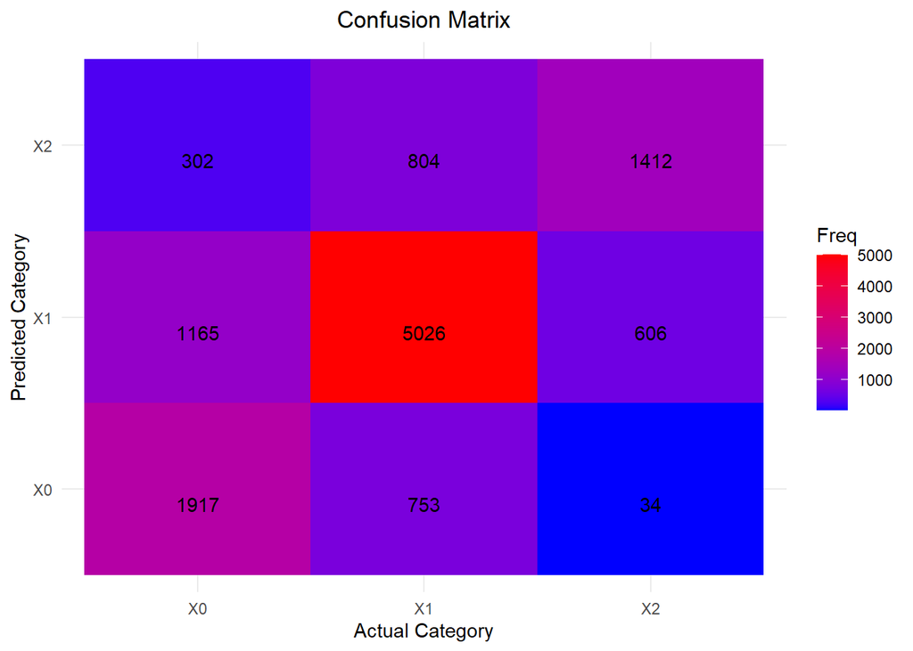

```r
# Visualize the model's confusion matrix
confusionMatrixTable <- as.table(conf_matrix)
ggplot(data = as.data.frame(confusionMatrixTable), aes(x = Actual, y = Predicted, fill = Freq)) +
  geom_tile() +
  geom_text(aes(label = Freq), vjust = 1.5, color = "black") +
  scale_fill_gradient(low = "blue", high = "red") +
  theme_minimal() +
  labs(title = "Confusion Matrix", x = "Actual Category", y = "Predicted Category") +
  theme(plot.title = element_text(hjust = 0.5))
```

```r
# Display the model results
print(paste("Test F1 Score:", f1_score_test))
```

```
## [1] "Test F1 Score: 0.66632570980162"
```

```r
print(paste("Test Accuracy:", accuracy_test))
```

```
## [1] "Test Accuracy: 0.69514934686746"
```

#### Algorithm Evaluation

The confusion matrix displays the counts of correct and incorrect predictions broken down by actual classes (X0, X1, X2) versus predicted classes (Package ‘Caret,’ 2023).  
In the test result. The best parameter is unveiled as Best Model Parameters: decay = 0.1. Correspondingly, the Test F1_Score = 0.666, Test Accuracy = 0.695 under the tuning results, indicating that the model is fairly good at identifying the correct classes but there might be room for improvement, particularly in reducing false positives and false negatives.

## 5.2 Knn

#### Algorithm Description

K-Nearest Neighbors (KNN) is an instance-based learning algorithm best suited to classification problems(Dynamic Selection of K Nearest Neighbors in Instance-based Learning, 2012). In this algorithm, the distance between a test sample and each training set sample is computed, and then the K nearest neighbors are selected to vote for the category assignment of the test sample. In this study, we are going to use this method to predict the credit score of customers according to “low”, “standard”, and “good”.

#### Advantages:

- KNN is easy to implement, understandable, and deploy.
- No need to make assumptions on data distribution; it is very robust to outliers and missing data(Soni, 2021).
- Being able to handle multi-classification problems makes it work well in solving our task of classification for credit scores.

#### Disadvantages:

- It is computationally costly when the number of data is large since it computes the distance of every pair of samples.
- An appropriate K value has to be set manually. If the K value is selected inappropriately, the related accuracy and generalization performance of the model will be affected.
- It is sensitive to the scale of the data because various scales of features lead to a problem in the result; thus, it requires proper scaling of the data(Soni, 2021).

```r
# load data
data_knn <- df5_with_credit_score

# set data type of the categorical columns
factor_columns_knn <- c("Occupation", "Credit_Mix", "Payment_of_Min_Amount", "Credit_Score")
data_knn[factor_columns_knn] <- lapply(data_knn[factor_columns_knn], as.factor)

# define target variable and the features
target_var_knn <- "Credit_Score"
features_knn <- data_knn[, setdiff(names(data_knn), target_var_knn)]
target_knn <- data_knn[[target_var_knn]]

# normalize these numeric columns
scale_columns_knn <- c("Annual_Income", "Monthly_Inhand_Salary", "Outstanding_Debt")
scaler_knn <- preProcess(data_knn[, scale_columns_knn], method = c("center", "scale"))
data_knn[, scale_columns_knn] <- predict(scaler_knn, data_knn[, scale_columns_knn])

# create a function to calculate F1 score
calculate_F1_Score_knn <- function(cm) {
  precision_knn <- diag(cm) / rowSums(cm)
  recall_knn <- diag(cm) / colSums(cm)
  f1_knn <- 2 * precision_knn * recall_knn / (precision_knn + recall_knn)
  return(mean(f1_knn, na.rm = TRUE))
}

# set seed and use cross-validation folds
set_seed_knn <- 5003
set.seed(set_seed_knn)
cv_folds_knn <- createFolds(target_knn, k = 10)

# initialize the results dataframe
evaluation_results_knn <- data.frame(K = integer(), Accuracy = numeric(), F1 = numeric())

# iterate through different values of k for model evaluation
k_values_knn <- seq(5, 15, by = 2)

for (k in k_values_knn) {
  fold_accuracies_knn <- numeric()
  fold_f1_scores_knn <- numeric()

  for (fold_index in seq_along(cv_folds_knn)) {
    test_indices_knn <- cv_folds_knn[[fold_index]]
    train_indices_knn <- setdiff(seq_len(nrow(data_knn)), test_indices_knn)

    train_set_knn <- data_knn[train_indices_knn, ]
    test_set_knn <- data_knn[test_indices_knn, ]

    # train and test KNN model
    knn_model_knn <- knn(train = train_set_knn[, setdiff(names(train_set_knn), target_var_knn)],
                         test = test_set_knn[, setdiff(names(test_set_knn), target_var_knn)],
                         cl = train_set_knn[[target_var_knn]],
                         k = k, prob = FALSE, use.all = TRUE)

    # calculate test set accuracy and F1 score
    actual_targets_knn <- test_set_knn[[target_var_knn]]
    confusion_matrix_knn <- table(Predictions = knn_model_knn, Actual = actual_targets_knn)
    accuracy_knn <- sum(diag(confusion_matrix_knn)) / sum(confusion_matrix_knn)
    f1_score_knn <- calculate_F1_Score_knn(confusion_matrix_knn)

    fold_accuracies_knn <- c(fold_accuracies_knn, accuracy_knn)
    fold_f1_scores_knn <- c(fold_f1_scores_knn, f1_score_knn)
  }

  # save the results of KNN
  evaluation_results_knn <- rbind(evaluation_results_knn, data.frame(K = k, Accuracy = mean(fold_accuracies_knn), F1 = mean(fold_f1_scores_knn)))
}

# output best results
optimal_results_knn <- evaluation_results_knn[which.max(evaluation_results_knn$Accuracy), ]
print(optimal_results_knn)
```

```
##   K  Accuracy        F1
## 3 9 0.7148253 0.6759193
```

#### Hyperparameter tuning

The reason behind the choices for k-value and range:

- To lessen the effect of noise: A small k value will be very susceptible to data noise, and a large k value can smooth the boundary of the classification decision; such a smoothing process is very effective in reducing the interference of noise with the prediction results(Band, 2023).
- Prevent overfitting or underfitting: A smaller value for K can have a huge overfitting model, meaning that the model is very sensitive to the training data and generally low; a larger value for K might also lead to a smaller one. The information in the data is not particularly sensitive to capture all the features in the data(Bohara, 2023).
- Computational Complexity: In a direct sense, the size of K also impacts the computational complexity. The larger the K, the more it takes for each prediction to compute, which is very important for working with large data(Bohara, 2023).

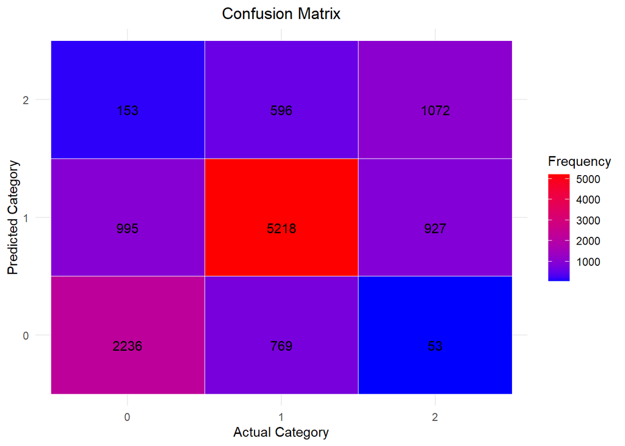

```r
# Load data
data_knn <- df5_with_credit_score

# Set the data type for categorical columns
factor_columns_knn <- c("Occupation", "Credit_Mix", "Payment_of_Min_Amount", "Credit_Score")
data_knn[factor_columns_knn] <- lapply(data_knn[factor_columns_knn], as.factor)

# Define target and feature variables
target_column_knn <- ncol(data_knn)
target_knn <- data_knn$Credit_Score

# Split data into training and test sets
set.seed(0)
train_index_knn <- createDataPartition(y = target_knn, p = 0.8, list = FALSE)
train_data_knn <- data_knn[train_index_knn, ]
test_data_knn <- data_knn[-train_index_knn, ]

# Normalize the specified columns
cols_to_scale_knn <- c("Annual_Income", "Monthly_Inhand_Salary", "Outstanding_Debt")
preProcValues_knn <- preProcess(train_data_knn[, cols_to_scale_knn], method = c("center", "scale"))
train_data_knn[, cols_to_scale_knn] <- predict(preProcValues_knn, train_data_knn[, cols_to_scale_knn])
test_data_knn[, cols_to_scale_knn] <- predict(preProcValues_knn, test_data_knn[, cols_to_scale_knn])

# Train the model with the best parameters specified
best_k_value_knn <- 9  # The optimal k value found in your analysis
knn_model_best_knn <- knn(train = train_data_knn[, -target_column_knn, drop = FALSE],
                          test = test_data_knn[, -target_column_knn, drop = FALSE],
                          cl = train_data_knn$Credit_Score,
                          k = best_k_value_knn,
                          prob = FALSE,
                          use.all = TRUE)

# Predictive test set
test_pred_knn <- knn_model_best_knn  # Store the prediction results
test_actual_knn <- test_data_knn$Credit_Score

# Calculate accuracy and F1 scores using the pre-defined F1 score function
conf_matrix_knn <- table(test_pred_knn = test_pred_knn, test_actual_knn = test_actual_knn)
accuracy_knn <- sum(diag(conf_matrix_knn)) / sum(conf_matrix_knn)
f1_score_knn <- calculate_F1_Score_knn(conf_matrix_knn)

# Create a data frame for the confusion matrix
conf_matrix_df <- as.data.frame(table(Prediction = test_pred_knn, Reference = test_actual_knn))
names(conf_matrix_df) <- c("Prediction", "Reference", "Frequency")

# Draw the confusion matrix plot
ggplot(conf_matrix_df, aes(x = Reference, y = Prediction, fill = Frequency)) +
  geom_tile(color = "white") +
  geom_text(aes(label = Frequency), vjust = 1.5, color = "black") +
  scale_fill_gradient(low = "blue", high = "red") +
  labs(title = "Confusion Matrix", x = "Actual Category", y = "Predicted Category") +
  theme_minimal() +
  theme(plot.title = element_text(hjust = 0.5))
```

```r
# Output the result of accuracy and F1 score
print(paste("Test accuracy:", accuracy_knn))
```

```
## [1] "Test accuracy: 0.709376820034945"
```

```r
print(paste("F1 score:", f1_score_knn))
```

```
## [1] "F1 score: 0.66941516786592"
```

## 5.3 random forest

#### Algorithm Description

Random Forest is a machine-learning algorithm based on decision tree ensemble learning. It enhances prediction accuracy, and the problem of overfitting is tackled by the use of multiple decision trees built and the consensus of the result (Whitfield, 2022). In this work, we have chosen this algorithm for several reasons. The Random Forest is simple, intuitive, and easy to implement.  
On the other hand, Random Forest does not assume any particular data distribution and is very robust to outliers and missing values (Shaikh, 2016). Data preprocessing has already taken the consideration of outliers and missing values, which gives a good foundation for this algorithm. Random Forest is suitable for multi-classification problems. Our target is to classify customers into “Poor”, “Standard”, and “Good” credit scores. Random Forest can well accommodate this type of multi-classification problem.

#### Advantages

- Random Forest works with a relatively low computational cost, mainly on clean datasets (AlmaBetter, 2023) since most data cleaning operations have been solved through the data preprocessing step.
- Random Forest does not have strict requirements on the distribution of the data (AlmaBetter, 2023), and it can work well even if the data has not been processed such as standardised or normalised.
- Random Forest works well with high dimensional data, i.e., where the number of features is high (Ghosh & Cabrera, 2022). Our dataset contains multiple features which can be effectively utilised by Random Forest to improve prediction accuracy.

#### Limitation

- Although we have dealt with outliers in the data preprocessing stage, the performance of the Random Forest may be affected if a high number of outliers are still present in some features (AlmaBetter, 2023).
- Random Forest requires manual selection of the number of decision trees and the size of its setting affects the fitting (Shaikh, 2016). Therefore, we need to select the optimal number of decision trees through methods such as cross-validation.
- Random Forest has relatively poor interpretability, especially when the number of decision trees is large (Shaikh, 2016).

```r
# load the data
data.rf <- df5_with_credit_score
data.rf$Occupation <- as.factor(data.rf$Occupation)
data.rf$Credit_Mix <- as.factor(data.rf$Credit_Mix)
data.rf$Payment_of_Min_Amount <- as.factor(data.rf$Payment_of_Min_Amount)
data.rf$Credit_Score <- as.factor(data.rf$Credit_Score)

set.seed(5003)

folds.rf <- createFolds(y = data.rf$Credit_Score, k = 10)

split_folds.rf <- function(x, dat){
  split_index.rf <- rep("training", nrow(dat))
  split_index.rf[x] <- "test"
  return(list(train = dat[which(split_index.rf == "training"),],
              test = dat[which(split_index.rf == "test"),]))
}
splited.list.rf <- lapply(folds.rf, split_folds.rf, dat = data.rf)

names(splited.list.rf) <- c(1:10)

doRandomForestCV <- function(x, label.name = "Credit_Score", tuneGrid = NULL) {
  training <- x$train
  test <- x$test

  # define cross-validation settings
  train_control <- trainControl(method = "cv", number = 5)

  # train the model with parameter tuning
  model <- train(as.formula(paste(label.name, "~ .")),
                 data = training,
                 method = "ranger",
                 tuneGrid = tuneGrid,
                 trControl = train_control)

  predicted <- predict(model, newdata = test)
  observed <- test[[label.name]]

  return(list(predicted = predicted,
              observed = observed,
              best_params = model$bestTune))
}

# define a grid of hyperparameters
tune_grid.cv.rf <- expand.grid(
  mtry = c(2, 4, 6),
  min.node.size = c(1, 3, 5),
  splitrule = c("gini", "extratrees")
)


res_10fold.rf <- lapply(splited.list.rf, doRandomForestCV, tuneGrid = tune_grid.cv.rf)

# calculate confusion matrix for each fold
conf_10fold.rf <- lapply(res_10fold.rf, function(x){
 predicted = x$predicted
 observed = x$observed
 caret::confusionMatrix(data = predicted, reference = observed)
})

metric_byClass.rf <- lapply(conf_10fold.rf, function(x){
 x$byClass
})
metrics.rf <- Reduce('+', metric_byClass.rf)/length(metric_byClass.rf)
fold_accuracies.rf <- sapply(conf_10fold.rf, function(x) {
 x$overall["Accuracy"]
})

# calculate mean accuracy
mean_accuracy.rf <- mean(fold_accuracies.rf)
f1_column.rf <- metrics.rf[, "F1"]
mean_f1.rf <- mean(f1_column.rf)

# Find the most frequent best parameters
best_params.list <- lapply(res_10fold.rf, function(x) x$best_params)
best_params.df <- do.call(rbind, best_params.list)
best_params.freq <- best_params.df %>%
  group_by(mtry, min.node.size, splitrule) %>%
  summarise(Count = n(), .groups = 'drop')

best_params <- best_params.freq[which.max(best_params.freq$Count),]
mtry.rf <- best_params$mtry
node_size.rf <- best_params$min.node.size
splitrule.rf <- levels(best_params$splitrule)[best_params$splitrule]
cat("Mean Accuracy:", mean_accuracy.rf,
    "\nMean F1 Score:", mean_f1.rf,
    "\nBest mtry:", mtry.rf,
    "\nBest min.node.size:", node_size.rf,
    "\nBest splitrule:", splitrule.rf, "\n")
```

```
## Mean Accuracy: 0.8228456
## Mean F1 Score: 0.8137609
## Best mtry: 4
## Best min.node.size: 5
## Best splitrule: extratrees
```

#### Hyperparameter Tuning

The grid search method was applied in the project to tune three key hyperparameters of the Random Forest and evaluate the performance of the model under different parameter combinations by cross-validation. First, we chose to tune the three hyperparameters: `mtry`, `min.node.size`, and `splitrule` (Wright et al., 2021). Among them, `mtry` represents the number of features applied at each split, and `min.node.size` is the least samples in the terminal node of the tree, and `splitrule` is the criterion of node-splitting. Next, a grid was created, containing combinations of candidate values for each hyperparameter. Models were then trained and evaluated for each combination, which is exhaustive but computationally intensive.

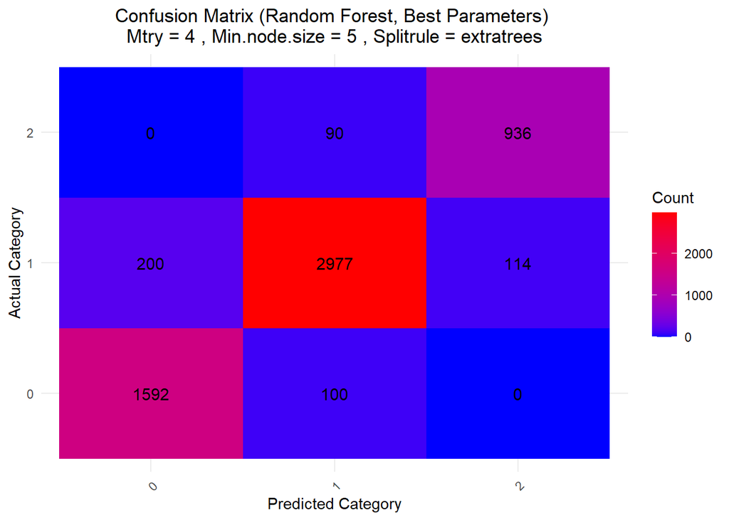

```r
# hyperparameter
best_model.rf <- train(Credit_Score ~ .,
                       data = data.rf,
                       method = "ranger",
                       tuneGrid = data.frame(mtry = mtry.rf,
                                             min.node.size = node_size.rf,
                                             splitrule = splitrule.rf),
                       trControl = trainControl(method = "cv", number = 10),
                       importance = "impurity")
data.test <- splited.list.rf[[1]]$test
predictions.test <- predict(best_model.rf, newdata = data.test)

cm.test <- confusionMatrix(data = predictions.test, reference = data.test$Credit_Score)
cm.df <- as.data.frame.matrix(cm.test$table)
colnames(cm.df) <- c("0", "1", "2")
cm.df.long <- data.frame(
  Actual = rep(c("0", "1", "2"), each = 3),
  Predicted = rep(c("0", "1", "2"), times = 3),
  Count = as.vector(cm.test$table)
)

cm.df.long$Actual <- factor(cm.df.long$Actual)
cm.df.long$Predicted <- factor(cm.df.long$Predicted)

# Revised plotting function
plot_cm.rf <- function(data, title) {
  ggplot(data, aes(x = Predicted, y = Actual, fill = Count)) +
    geom_tile() +
    geom_text(aes(label = Count), vjust = 0.5, color = "black", size = 4) +
    scale_fill_gradient(low = "blue", high = "red") +
    labs(title = title, x = "Predicted Category", y = "Actual Category") +
    theme_minimal() +
    theme(axis.text.x = element_text(angle = 45, hjust = 1),
          plot.title = element_text(hjust = 0.5))
}

plot_title.rf <- paste("Confusion Matrix (Random Forest, Best Parameters)",
                       "\nMtry =", mtry.rf, ", Min.node.size =", node_size.rf,
                       ", Splitrule =", splitrule.rf)
plot_cm.rf(cm.df.long, plot_title.rf)
```

#### Algorithm evaluation

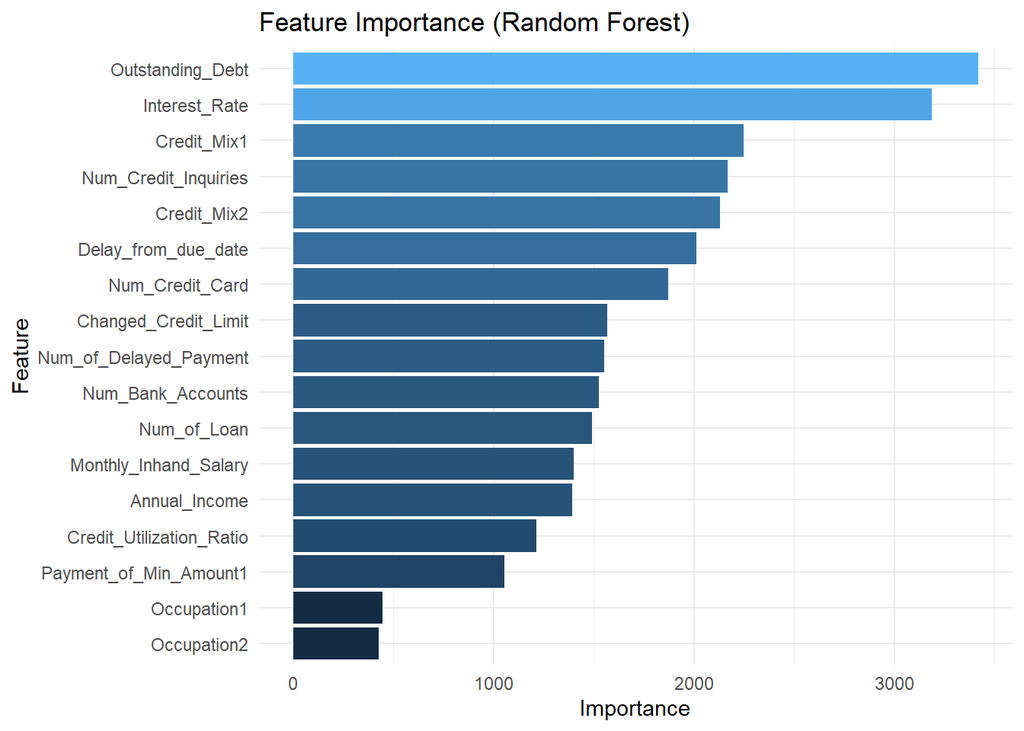

```r
# plot feature importance
importance_scores.rf <- importance(best_model.rf$finalModel, type = 1)  # Type 1 for variable importance
if ("ranger" %in% class(best_model.rf$finalModel)) {
  importance_scores.rf <- best_model.rf$finalModel$variable.importance
}
importance_df.rf <- data.frame(
  Feature = names(importance_scores.rf),
  Importance = importance_scores.rf,
  stringsAsFactors = FALSE
)
importance_df.rf <- importance_df.rf[order(importance_df.rf$Importance, decreasing = TRUE), ]

ggplot(importance_df.rf, aes(x = reorder(Feature, Importance), y = Importance, fill = Importance)) +
  geom_bar(stat = "identity") +
  coord_flip() +
  labs(title = "Feature Importance (Random Forest)",
       x = "Feature",
       y = "Importance") +
  theme_minimal() +
  theme(legend.position = "none")
```

## 5.4 Decision Tree

#### Algorithm Description

A decision tree classifier is a popular machine learning algorithm used for classification tasks. It starts with the entire dataset at the root node, and then splits the dataset into subsets based on the feature that provides the best split according to a chosen criterion (e.g., information gain).(K.Rai, MS Devi, 2016) This process is repeated recursively for each subset, creating a tree-like structure. At each node, the algorithm selects the feature and the criterion that best separates the data into purest subsets in order to maximize information gain. This repeated splitting process continues until one of the stopping criteria is met, such as reaching a maximum depth, or no further improvement in gaining information.(Sharad Saxena, 2022)

#### Advantages:

Interpretability: Decision trees are easy to interpret. The model’s decision-making process can be visualized, making it useful for explaining predictions to stakeholders.(O. Z. Maimon, L. Rokach, 1997)

Not assuming linear relationships: Decision trees do not assume linear relationships between features and the target variable to be linear and is able to capture non-linear relationships.(E Demirović, PJ Stuckey, 2021)

Feature importance: Decision trees provide a measure of feature importance, allowing users to identify the most useful features for prediction.(MRA Iqbal, MS Rahaman, SI Nabil, 2012)

#### Disadvantages:

Prone to overfitting: Decision trees tend to overfit the training data, especially when the tree depth is not controlled or when the dataset is noisy, which may lead to poor generalization performance on unseen data.(A. Amro, M. Al-Akhras, 2021)

Bias towards Dominant Classes: Decision trees, especially with unbalanced class distributions, may bias towards the majority class, resulting in poor performance for minority classes.(I. Chaabane, R. Guermazi, M. Hammami, 2020)

Instability: Since decision trees make decisions based on the optimal splits, minor changes in the dataset may lead to different feature selections or thresholds. This instability can affect the robustness of the model, especially when the dataset is noisy or when there are multiple features with similar predictive power.(R. H. Li, G. G. Belford 2002)

```r
# load the data
data.dt <- df5_with_credit_score

# set seed
set.seed(1)

# create folds for cross-validation
folds.dt <- createFolds(y = data.dt$Credit_Score, k = 10)

# define function to split data
split_folds <- function(x, dat){
  split_index <- rep("training", nrow(dat))
  split_index[x] <- "test"
  return(list(train = dat[which(split_index == "training"),],
              test = dat[which(split_index == "test"),]))
}

# apply split function to each fold and store results in a list
splited.list <- lapply(folds.dt, split_folds, dat = data.dt)

# assign names to the splited lists
names(splited.list) <- c(1:10)

# create function for applying decision tree
doDecisionTree <- function(x, label.name = "Credit_Score", tuneGrid = NULL) {
  training <- x$train
  test <- x$test

  training[[label.name]] <- factor(training[[label.name]], levels = 0:2)
  test[[label.name]] <- factor(test[[label.name]], levels = 0:2)

  feature.vars <- !names(training) %in% label.name

  # perform parameter tuning
  if (!is.null(tuneGrid)) {
    ctrl <- trainControl(method = "cv", number = 5)
    model <- train(as.formula(paste(label.name, "~ .")),
                   data = training,
                   method = "rpart",
                   tuneGrid = tuneGrid,
                   trControl = ctrl)
  } else {
    # fit decision tree model
    model <- tree(formula = paste(label.name, "~ ."), data = training)
  }

  # plot the decision tree
  plot(model)

  # get class predictions
  predicted <- predict(model, newdata = test)
  observed <- test[[label.name]]

  return(list(predicted = predicted, observed = observed))
}

# define a grid of hyperparameters
tuneGrid.dt <- expand.grid(cp = seq(0.01, 1, by = 0.01))

# apply decision tree with parameter tuning
res_10fold <- lapply(splited.list, doDecisionTree, tuneGrid = tuneGrid.dt)

# calculate confusion matrix for each fold
conf_10fold <- lapply(res_10fold, function(x){
  predicted = x$predicted
  observed = x$observed
  caret::confusionMatrix(data = predicted, reference = observed)
})

# get metrics from each confusion matrix
metric_byClass <- lapply(conf_10fold, function(x){
  x$byClass
})

# calculate the mean of metrics of all folds
metrics.dt <- Reduce('+', metric_byClass)/length(metric_byClass)

# get the accuracy of each fold
fold_accuracies <- sapply(conf_10fold, function(x) {
  x$overall["Accuracy"]
})

# calculate mean accuracy of all folds
mean_accuracy.dt <- mean(fold_accuracies)

# print mean accuracy
print(paste("Mean Accuracy:", mean_accuracy.dt))
```

```
## [1] "Mean Accuracy: 0.702712092153223"
```

```r
# get the F1 score of each class
f1_column.dt <- metrics.dt[, "F1"]

# calculate the mean F1 score
mean_f1.dt <- mean(f1_column.dt)

# print mean F1 score
print(paste("Mean F1 Score:", mean_f1.dt))
```

```
## [1] "Mean F1 Score: 0.686934707534086"
```

```r
# get performance metrics for each fold
performance_metrics.dt <- lapply(conf_10fold, function(x) x$overall["Accuracy"])

# find the index of the best-performing model
best_model_index.dt <- which.max(performance_metrics.dt)

# get predictions from the best-performing model
best_model_predictions.dt <- res_10fold[[best_model_index.dt]]$predicted
best_model_observed.dt <- res_10fold[[best_model_index.dt]]$observed

# calculate the confusion matrix for the best model
conf_matrix_best_model.dt <- confusionMatrix(data = best_model_predictions.dt, reference = best_model_observed.dt)

# get accuracy of the best model
best_model_metrics.dt <- conf_10fold[[best_model_index.dt]]$overall
best_model_accuracy.dt <- best_model_metrics.dt["Accuracy"]

# get F1-score of the best model
best_model_f1_score.dt <- F1_Score(y_pred = best_model_predictions.dt, y_true = best_model_observed.dt)

# best model acc
print(paste("Best Model Accuaracy:", best_model_accuracy.dt))
```

```
## [1] "Best Model Accuaracy: 0.71846921797005"
```

```r
# best model f1
print(paste("Best Model F1-Score:", best_model_f1_score.dt))
```

```
## [1] "Best Model F1-Score: 0.714365881032548"
```

#### Hyperparameter tuning

The hyperparameter being tuned for the decision tree model is the complexity parameter (‘cp’). The ‘tuneGrid.dt’ grid specifies the range of values for ‘cp’ from 0.01 to 1, incrementing by 0.01. The complexity parameter represents the cost of adding another split to the model. It represents the trade-off between the complexity of the tree in terms of number of splits and its goodness of fit to the training data. A smaller ‘cp’ value results in a more complex tree with more splits, adding to the possibility of overfitting of the model to the training dataset, while a larger ‘cp’ value leads to a simpler tree with fewer splits.(RG Mantovani, T Horváth, ALD Rossi, 2023)

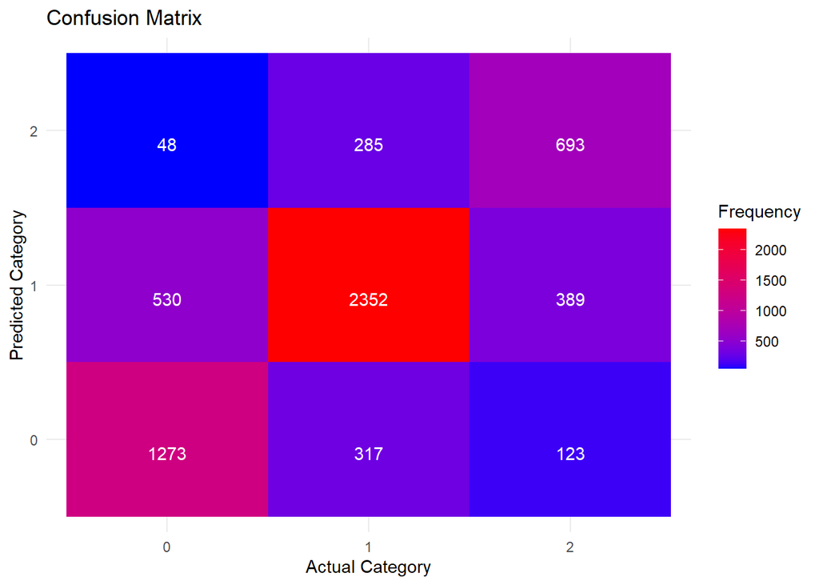

```r
# visualize confusion matrix
cm_matrix.dt <- as.data.frame(conf_matrix_best_model.dt$table)
colnames(cm_matrix.dt) <- c("Reference", "Prediction", "Frequency")
ggplot(data = cm_matrix.dt, aes(x = Reference, y = Prediction, fill = Frequency)) +
    geom_tile() +
    geom_text(aes(label = Frequency), vjust = 1.5, color = "white") +
    scale_fill_gradient(low = "blue", high = "red") +
    labs(title = "Confusion Matrix", x = "Actual Category", y = "Predicted Category") +
    theme_minimal()
```

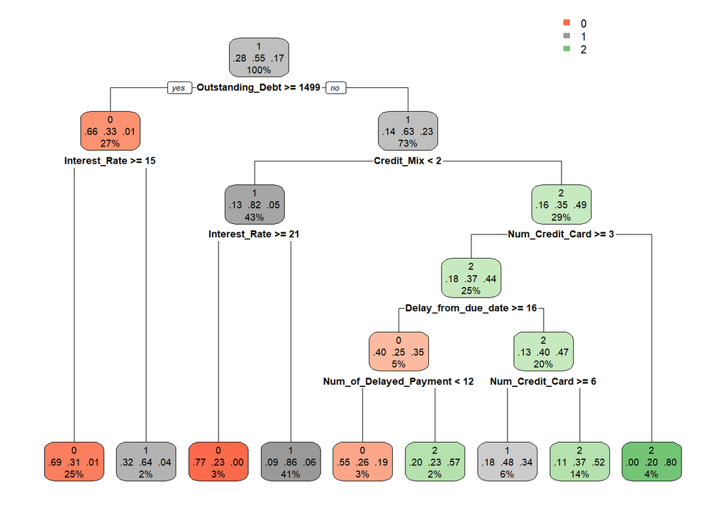

```r
# create function for applying decision tree
doDecisionTree.1 <- function(x, label.name = "Credit_Score", tuneGrid = NULL) {

  # get training and test set
  training <- x$train
  test <- x$test

  # convert label to 0, 1, and 2
  training[[label.name]] <- factor(training[[label.name]], levels = 0:2)
  test[[label.name]] <- factor(test[[label.name]], levels = 0:2)

  # build decision tree model with cross-validation
  if (!is.null(tuneGrid)) {
    ctrl <- trainControl(method = "cv", number = 5)
    model <- train(as.formula(paste(label.name, "~ .")),
                   data = training,
                   method = "rpart",
                   tuneGrid = tuneGrid,
                   trControl = ctrl)$finalModel
  } else {
    model <- rpart(as.formula(paste(label.name, "~ .")), data = training)
  }

  # get predictions
  predicted <- predict(model, newdata = test, type = "class")
  observed <- test[[label.name]]
  accuracy <- sum(predicted == observed) / length(observed)

  # return results
  return(list(model = model, predicted = predicted, observed = observed, accuracy = accuracy))
}

# get the results using the above function
results.dt <- lapply(splited.list, doDecisionTree.1, tuneGrid = expand.grid(cp = seq(0.01, 0.1, by = 0.01)))

# find the index of best model
best_model_index.dt <- which.max(sapply(results.dt, function(x) x$accuracy))
best_model.dt <- results.dt[[best_model_index.dt]]$model

# plot the best decision tree model
rpart.plot(best_model.dt)
```

#### Algorithm evaluation

As shown in the confusion matrix, it is confirmed that the accuracy achieved in the largest class (‘Standard’) is the greatest among all classes. The underperformance in the other two classes is to be expected due to a decision tree’s shortcoming of bias towards dominant class but could be also due to the model’s overfitting nature. Despite this, both F1-score and accuracy demonstrate a reasonable prediction result for the best model, with F1-score being 0.714 and accuracy 0.718, indicating an overall decent performance on the dominant class, if not the minority classes.

## 5.5 SVM

#### Algorithm Description

SVC is a variant of SVM for classification tasks. The goal of SVC is to find the best hyperplane to separate different classes of data points at the greatest interval, by which to maximise the difference between different classes, and to maximise the distance of support vectors to this hyperplane, and by using kernel functions, SVC can handle nonlinear relationships by mapping data to higher dimensional Spaces(Gholami & Fakhari, 2017).

#### Advantages

- Can handle multi-classification problems, SVC can be extended to multi-classification problems through effective strategies.
- Strong generalisation ability, able to deal with overfitting problems.
- Strong flexibility, which can handle the nonlinear problems of the data set by adjusting the kernel function.
- Strong robustness, insensitive to outliers.

#### Disadvantages

- For large-scale data sets, the data cost is high and the training time is long
- Sensitive to parameter selection
- Poor interpretability

So I chose SVC to deal with the classification problem of credit scores, its ability to efficiently handle high and non-linear data, and the problem of multiple classifications. Although it brings some challenges, such as the complexity of parameter selection and high computational cost, these problems can be solved to a certain extent with appropriate technologies and strategies.

```r
# load dataset
data <- df5_with_credit_score
set.seed(5003)
# Divide the data set into a training set and a test set
trainIndex <- createDataPartition(data$Credit_Score, p = .7, list = FALSE)
train <- data[trainIndex, ]
test <- data[-trainIndex, ]
# Convert to a factor type variable
train$Credit_Score <- factor(train$Credit_Score)
test$Credit_Score <- factor(test$Credit_Score)

# grid search
train_control_svm <- trainControl(method = "cv", number = 10)
tune_grid <- expand.grid(C = c(0.1, 10),
                         sigma = c(0.01, 0.1))
svm_model <- train(Credit_Score ~ ., data = train, method = "svmRadial",
                   trControl = train_control_svm, tuneGrid = tune_grid, preProcess = "scale")
print(svm_model$bestTune)
```

```
##   sigma  C
## 4   0.1 10
```

#### Hyperparameter Tuning

For the construction of SVM model, C value, Kernel and Sigma are selected to build the model. C value controls the model’s penalty for wrong classification to balance the accuracy and generalization ability of the model on the training set. A smaller C value means that the model has a greater tolerance for errors. It will improve the generalization ability of the model but may lead to underfitting, while a larger C value, on the contrary, may lead to overfitting. Kernel is used to determine how data is mapped to the high-dimensional space. By selecting different kernels, linearly indivisible data sets in the original space can become distinguishable. In this model construction, RBF is chosen, because the Kernel is more suitable for processing complex linear indivisible data. The parameter Sigma controls the Kernel width. By increasing the value of Sigma, the model can better capture the details in the data, but there is the risk of overfitting. In order to select the best parameters, grid search is used to tune parameters, and finally the best parameters are found (C: 10, Sigma: 0.1, Kernel: RBF).

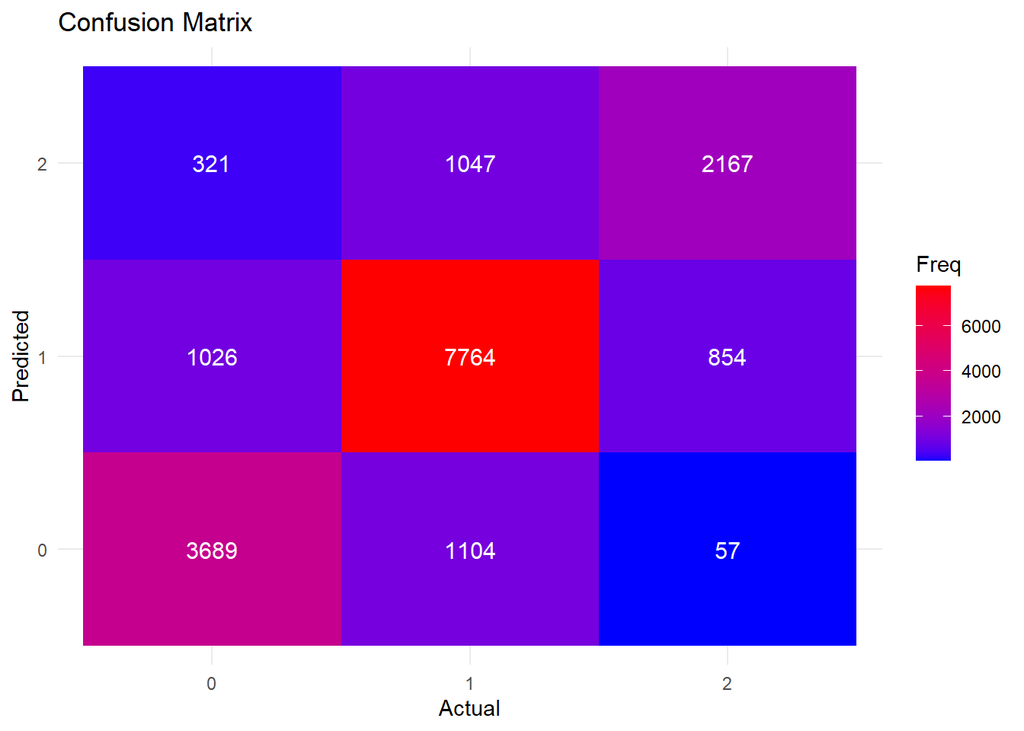

```r
# Make predictions on the test set
predictions_svm <- predict(svm_model, test[, -which(names(test) == "Credit_Score")], probability = TRUE)
# Make sure factor level of predicted value and true label match all levels of the test set
all_levels <- sort(unique(test$Credit_Score))
predictions_svm <- factor(predictions_svm, levels = all_levels)
true_y <- factor(test[, "Credit_Score"], levels = all_levels)
# Get confusion matrix
conf_matrix_svm <- confusionMatrix(predictions_svm, true_y)
cm_df <- as.data.frame.table(conf_matrix_svm$table)

ggplot(data = cm_df, aes(x = Reference, y = Prediction, fill = Freq)) +
  geom_tile() +
  scale_fill_gradient(low = "blue", high = "red") +
  geom_text(aes(label = Freq), color = "white", size = 4) +
  labs(title = "Confusion Matrix", x = "Actual", y = "Predicted", fill = "Freq") +
  theme_minimal()
```

```r
# Get accuracy and f1_score
accuracy <- conf_matrix_svm$overall['Accuracy']

f1_scores <- sapply(levels(true_y), function(level) {
  if (sum(predictions_svm == level) == 0 || sum(true_y == level) == 0) {
    return(NA)
  } else {
    return(F1_Score(y_pred = predictions_svm[true_y == level], y_true = true_y[true_y == level]))
  }
})

# Get the average of F1 scores
f1_score <- mean(f1_scores, na.rm = TRUE)

print(paste("Accuracy:", accuracy))
```

```
## [1] "Accuracy: 0.755449553497143"
```

```r
print(paste("F1 Score:", f1_score))
```

```
## [1] "F1 Score: 0.845616045845272"
```

#### Algorithm evaluation

For the evaluation phase of the model, we plotted the confusion matrix of the SVM model and evaluated the model by calculating its accuracy and F1 score. These charts show the performance of the optimized SVM model. The confusion matrix shows high prediction accuracy, especially for class 1 (Standard), although the other two classes are slightly less discriminative. Both performance metrics also show good F1 scores and accuracy, which also highlight the effective tuning of multi-class classification, indicating good overall model performance.

# 6 Classification performance evaluation

The classification models, including Random Forest, Support Vector Machine (SVM), K-Nearest Neighbors (KNN), Decision Tree, and Logistic Regression, are to be compared. This part of the analysis is based on two performance metrics, F1-score and accuracy.

#### Comparison by F1-score

| Model | F1-score |
| --- | --- |
| SVM | 0.846 |
| Random Forest | 0.814 |
| Decision Tree | 0.714 |
| KNN | 0.669 |
| Logistic Classification | 0.666 |

The F1-scores for the models are as follows: SVM achieved the highest F1-score of 0.846, Random Forest 0.814, Decision Tree 0.714, KNN 0.669, and Logistic Regression 0.666. These scores provide insight into the models’ ability to balance precision and recall, with higher values indicating better performance in capturing both true positives and true negatives.

#### Comparison by Accuracy

| Model | Accuracy |
| --- | --- |
| Random Forest | 0.823 |
| SVM | 0.755 |
| Decision Tree | 0.718 |
| KNN | 0.709 |
| Logistic Classification | 0.695 |

In terms of accuracy, which measures the overall correctness of the predictions, the models perform as follows: Random Forest reached the highest score of 0.823, followed by SVM(0.755), Decision Tree(0.718), KNN(0.709), with Logistic Regression still at the bottom of the list (0.695). While accuracy is an essential metric, it should be interpreted alongside F1-score to gain a comprehensive understanding of model performance.

# 7 Conclusion

This project applies machine learning algorithms to construct credit score prediction models based on various demographic and financial attributes of customers. Among several employed classification algorithms, the Random Forest model demonstrates the best performance in accuracy and model stability. However, limitations still exist:

Despite providing feature importance metrics, the interpretability of the Random Forest model remains limited, especially with a large number of decision trees. To enhance interpretability, selecting the most predictive feature subset based on feature importance can reduce model complexity.

Future work can focus on addressing these issues to further optimize model performance using the mentioned techniques. Additionally, exploring integration of credit score prediction with other business scenarios, in collaboration with domain experts, can lead to more practical credit scoring mechanisms.

# 8 Reference

‌A. Amro, M. Al-Akhras (2021), Avoiding Overfitting of Decision Trees. https://link.springer.com/content/pdf/10.1007/978-1-84628-766-4_8.pdf  
‌Abdi, H., & Williams, L. J. (2010). Principal component analysis. Wiley Interdisciplinary Reviews. Computational Statistics, 2(4), 433–459. https://doi.org/10.1002/wics.101  
‌Abdi, H., Williams, L. J., & Valentin, D. (2013). Multiple factor analysis: principal component analysis for multitable and multiblock data sets. Wiley Interdisciplinary Reviews. Computational Statistics, 5(2), 149–179. https://doi.org/10.1002/wics.1246  
‌Allibhai, J. (2022, June 21). Building a k-Nearest-Neighbors (k-NN) Model with Scikit-learn. Medium. https://towardsdatascience.com/building-a-k-nearest-neighbors-k-nn-model-with-scikit-learn-51209555453a  
‌Allison, P. (2024, March 12). How Relevant is the Independence of Irrelevant Alternatives? Statistical Horizons. https://statisticalhorizons.com/iia/  
‌AlmaBetter. (2023, April 12). Random Forest Algorithm in Machine Learning. AlmaBetter. https://www.almabetter.com/bytes/tutorials/data-science/random-forest  
‌Band, A. (2023, December 12). How to find the optimal value of K in KNN? - Towards Data Science. Medium. https://towardsdatascience.com/how-to-find-the-optimal-value-of-k-in-knn-35d936e554eb  
‌Bohara, R. K. (2023, October 29). How to find the optimal value of K in KNN? - Rohan Kumar Bohara - Medium. Medium. https://medium.com/@rkbohara097/how-to-find-the-optimal-value-of-k-in-knn-2d5177430f2a  
‌Demir-Kavuk, O., Kamada, M., Akutsu, T., & Knapp, E. (2011). Prediction using step-wise L1, L2 regularization and feature selection for small data sets with large number of features. BMC Bioinformatics, 12(1). https://doi.org/10.1186/1471-2105-12-412  
‌Dynamic selection of k nearest neighbors in instance-based learning. (2012, August 1). IEEE Conference Publication | IEEE Xplore. https://ieeexplore.ieee.org/abstract/document/6302995  
‌E Demirović, PJ Stuckey (2021), Optimal Decision Trees for Nonlinear Metrics. https://ojs.aaai.org/index.php/AAAI/article/view/16490  
‌El-Habil, A. M. (2012). An application on multinomial logistic regression model. Pakistan Journal of Statistics and Operation Research, 8(2), 271. https://doi.org/10.18187/pjsor.v8i2.234  
‌Fushiki, T. (2009). Estimation of prediction error by using K-fold cross-validation. Statistics and Computing, 21(2), 137–146. https://doi.org/10.1007/s11222-009-9153-8  
‌GeeksforGeeks. (2024, April 5). Feature Importance with Random Forests. GeeksforGeeks; GeeksforGeeks. https://www.geeksforgeeks.org/feature-importance-with-random-forests/  
‌Gholami, R., & Fakhari, N. (2017). Support Vector Machine: Principles, Parameters, and Applications. In Handbook of Neural Computation (pp. 515-535). Academic Press. https://doi.org/10.1016/B978-0-12-811318-9.00027-2  
‌Ghosh, D., & Cabrera, J. (2022). Enriched Random Forest for High Dimensional Genomic Data. IEEE/ACM Transactions on Computational Biology and Bioinformatics, 19(5), 2817–2828. https://doi.org/10.1109/tcbb.2021.3089417  
‌Hamid, Y., & M. Sugumaran. (2019). A t-SNE based non linear dimension reduction for network intrusion detection. International Journal of Information Technology, 12(1), 125–134. https://doi.org/10.1007/s41870-019-00323-9  
‌I. Chaabane, R. Guermazi, M. Hammami (2020), Enhancing techniques for learning decision trees from imbalanced data. https://link.springer.com/article/10.1007/s11634-019-00354-x  
‌Kajal Rai, M. Syamala Devi, Ajay Guleri.(2016, January) Decision Tree Based Algorithm for Intrusion Detection. https://www.researchgate.net/publication/298175900  
‌Kook, L., Herzog, L., Hothorn, T., Dürr, O., & Sick, B. (2022). Deep and interpretable regression models for ordinal outcomes. Pattern Recognition, 122, 108263. https://doi.org/10.1016/j.patcog.2021.108263  
‌MRA Iqbal, MS Rahaman, SI Nabil (2012), Construction of Decision Trees by Using Feature Importance Value for Improved Learning Performance. https://link.springer.com/chapter/10.1007/978-3-642-34481-7_30  
‌O. Z. Maimon, L. Rokach (1997), Data Mining With Decision Trees: Theory And Applications. Data mining with decision trees: theory and applications  
‌Package ‘caret.’ (2023). https://cran.radicaldevelop.com/web/packages/caret/caret.pdf  
‌Paris, R. (2022). Credit score classification. Kaggle.com. https://www.kaggle.com/datasets/parisrohan/credit-score-classification/data?select=train.csv  
‌Prinzie, A., & Van Den Poel, D. (2008). Random Forests for multiclass classification: Random MultiNomial Logit. Expert Systems With Applications, 34(3), 1721–1732. https://doi.org/10.1016/j.eswa.2007.01.029  
‌R. H. Li, G. G. Belford (2002), Instability of decision tree classification algorithms. https://dl.acm.org/doi/abs/10.1145/775047.775131  
‌Review of Smart Meter Data Analytics: Applications, Methodologies, and Challenges. (n.d.). IEEE Journals & Magazine | IEEE Xplore. https://ieeexplore.ieee.org/abstract/document/8322199?casa_token=6GI9EsmFwpoAAAAA:3fIJojk8DdWgiBQATlfky59DjZEykcm4HqKPr5vQNQe39-yNOzXtiFZ0cv6Vf7CayhLENO-niQ  
‌RG Mantovani, T Horváth, ALD Rossi (2023, December), Better Trees: An empirical study on hyperparameter tuning of classification decision trees. https://www.researchgate.net/publication/329465048_Better_Trees_An_empirical_study_on_hyperparameter_tuning_of_classification_decision_trees  
‌S Saxena (2022), Tree-Based Machine Learning Methods in SAS Viya. Tree-Based Machine Learning Methods in SAS Viya  
‌Shaikh, J. (2016, December 5). 45 questions to test Data Scientists on Tree Based Algorithms (Decision tree, Random Forests, XGBoost). Analytics Vidhya. https://www.analyticsvidhya.com/blog/2016/12/detailed-solutions-for-skilltest-tree-based-algorithms/  
‌Shaikh, J. (2016, December 5). 45 questions to test Data Scientists on Tree Based Algorithms (Decision tree, Random Forests, XGBoost). Analytics Vidhya. https://www.analyticsvidhya.com/blog/2016/12/detailed-solutions-for-skilltest-tree-based-algorithms/  
‌Soni, A. (2021, December 15). Advantages And Disadvantages of KNN - Anuuz Soni - Medium. Medium. https://medium.com/@anuuz.soni/advantages-and-disadvantages-of-knn-ee06599b9336  
‌Whitfield, B. (2022). Random Forest: A Complete Guide for Machine Learning. Built In. https://builtin.com/data-science/random-forest-algorithm  
‌Wright, M., Wager, S., Probst, P., & Maintainer. (2021). Package “ranger” Type Package Title A Fast Implementation of Random Forests. https://cran.r-project.org/web/packages/ranger/ranger.pdf

# 9 Contribution Statement

All members contribute equally to all aspects of this project.